# Multilevel Analysis of Trust in Parliament

Vencz Balázs

2026-09-05

# Introduction

This project examines regional and country-level differences in trust in parliament using data from Round 11 of the European Social Survey. Respondents are nested within regions, while regions are nested within countries. Multilevel linear models are used to account for this hierarchical structure.

# Data preparation

## Required packages

The following packages are used for data manipulation, multilevel modelling and visualisation.

```r
library(dplyr)
library(tidyr)
library(lme4)
library(ggplot2)
```

## Importing the ESS Round 11 dataset

The analysis uses the integrated European Social Survey Round 11 dataset. The dataset contains individual-level survey responses from 30 participating countries.

```r
# Import the complete ESS Round 11 dataset.
ess_raw <- read.csv(
  "ESS11.csv"
)
```

## ESS analysis weight

The ESS provides several survey weights. This project uses the analysis weight (`anweight`), which combines the post-stratification weight and the population-size weight. The variable is copied to the shorter name `weight` for use in the subsequent regression models.

Before estimating the models, the weight is examined for missing, zero and negative values. Valid regression weights must be available and greater than zero.

```r
# Store the ESS analysis weight in a shorter variable.
ess_raw$weight <- ess_raw$anweight

# Display the distribution of the analysis weight.
summary(ess_raw$weight)
```

```
##      Min.   1st Qu.    Median      Mean   3rd Qu.      Max.
##  0.002015  0.175897  0.433793  0.932035  1.216379 12.997417
```

```r
# Count missing analysis weights.
sum(
  is.na(ess_raw$weight)
)
```

```
## [1] 0
```

```r
# Count zero or negative analysis weights.
sum(
  ess_raw$weight <= 0,
  na.rm = TRUE
)
```

```
## [1] 0
```

The summary shows the distribution and range of the ESS analysis weight. The following two results indicate the number of missing and non-positive weights. Ideally, both values should equal zero.

## Initial examination of the dataset

The dimensions of the dataset show the total number of respondents and variables. The country-frequency table reports the number of respondents included from each participating country before handling missing values in the variables used by the models.

```r
# Display the dimensions of the complete dataset.
dim(ess_raw)
```

```
## [1] 50116   692
```

```r
# Display the distribution of respondents across countries.
table(
  ess_raw$cntry,
  useNA = "ifany"
)
```

```
##
##   AT   BE   BG   CH   CY   DE   EE   ES   FI   FR   GB   GR   HR   HU   IE   IL
## 2354 1594 2239 1384  685 2420 1293 1844 1563 1771 1684 2757 1563 2118 2017  906
##   IS   IT   LT   LV   ME   NL   NO   PL   PT   RS   SE   SI   SK   UA
##  842 2865 1365 1252 1609 1695 1337 1442 1373 1563 1230 1248 1442 2661
```

# Variable selection and definition

The analysis requires variables identifying the hierarchical structure of the data, the dependent variable, the religiosity predictors, the control variables and the ESS analysis weight. Only these variables are retained in the multilevel working dataset.

## Variables included in the analysis

| Variable | Meaning | Role in the analysis |
| --- | --- | --- |
| `idno` | Respondent identification number | Individual identifier |
| `cntry` | Country code | Level-3 grouping variable |
| `region` | ESS regional code | Basis of the Level-2 grouping variable |
| `regunit` | Type or level of regional classification | Regional metadata and data check |
| `weight` | ESS analysis weight derived from `anweight` | Survey weight |
| `trstprl` | Trust in the country’s parliament, measured from 0 to 10 | Dependent variable |
| `rlgdgr` | Self-rated religiosity, measured from 0 to 10 | Religiosity predictor |
| `rlgatnd` | Frequency of attending religious services | Religiosity predictor |
| `pray` | Frequency of praying outside religious services | Religiosity predictor |
| `agea` | Respondent’s age in years | Control variable |
| `gndr` | Respondent’s gender | Control variable |
| `eisced` | Harmonised ES-ISCED educational level | Control variable |
| `polintr` | Interest in politics | Control variable |

Trust in parliament (`trstprl`) is the dependent variable in every regression model. The three religiosity variables are the main explanatory variables. Age, gender, education and political interest are included as individual-level controls.

The original `rlgatnd`, `pray` and `polintr` variables are coded so that lower values represent greater frequency or interest. These variables are therefore reversed later so that higher values consistently indicate greater religious activity or political interest.

## Defining the required variables

```r
# Variables required for identifying respondents,
# regions and countries.
structure_vars <- c(
  "idno",
  "cntry",
  "region",
  "regunit",
  "weight"
)

# Dependent variable:
# trust in the country's parliament.
inst_var <- c(
  "trstprl"
)

# Main religiosity predictors.
rel_vars <- c(
  "rlgdgr",
  "rlgatnd",
  "pray"
)

# Individual-level control variables.
control_vars <- c(
  "agea",
  "gndr",
  "eisced",
  "polintr"
)

# Combine all required raw variables.
required_vars <- c(
  structure_vars,
  inst_var,
  rel_vars,
  control_vars
)

# Identify any required variables that are not
# available in the imported dataset.
missing_variables <- setdiff(
  required_vars,
  names(ess_raw)
)

# Stop the analysis if a required variable is missing.
if (length(missing_variables) > 0) {
  stop(
    paste(
      "The following required variables are missing:",
      paste(
        missing_variables,
        collapse = ", "
      )
    )
  )
}
```

## Creating the multilevel working dataset

The original ESS Round 11 dataset contains several hundred variables that are not required for the present analysis. A smaller working dataset is therefore created containing only the respondent identifier, grouping variables, survey weight, dependent variable, religiosity predictors and control variables.

```r
# Keep all respondents but retain only the variables
# required for the planned multilevel analysis.
# Keep the variables required for the multilevel analysis.
ess_mlm <- ess_raw %>%
  dplyr::select(
    all_of(required_vars)
  )

# Display the dataset dimensions and variable names.
dim(ess_mlm)
```

```
## [1] 50116    13
```

```r
names(ess_mlm)
```

```
##  [1] "idno"    "cntry"   "region"  "regunit" "weight"  "trstprl" "rlgdgr"
##  [8] "rlgatnd" "pray"    "agea"    "gndr"    "eisced"  "polintr"
```

## Cleaning and recoding the religiosity variables

Three variables are used to represent different dimensions of religiosity:

| Variable | Dimension | Original direction | Final direction |
| --- | --- | --- | --- |
| `rlgdgr` | Self-rated religiosity | Higher values indicate greater religiosity | Unchanged |
| `rlgatnd` | Attendance at religious services | Lower values indicate more frequent attendance | Reversed |
| `pray` | Frequency of praying | Lower values indicate more frequent prayer | Reversed |

The ESS uses the values 77, 88 and 99 to represent refusal, “don’t know” and no answer. These values are not substantive responses and are therefore converted to missing values (`NA`).

Religious attendance and prayer frequency originally range from 1 to 7, with lower values representing more frequent religious activity. These variables are reversed using $8-x$. After recoding, both variables range from 1 to 7, with higher values indicating more frequent religious activity.

```r
# Replace the special ESS missing-value codes with NA.
ess_mlm <- ess_mlm %>%
  mutate(
    across(
      all_of(rel_vars),
      ~ ifelse(
        .x %in% c(77, 88, 99),
        NA,
        .x
      )
    )
  )

# Reverse religious attendance and prayer frequency.
#
# Original coding:
# lower values = more frequent religious activity.
#
# Recoded variables:
# higher values = more frequent religious activity.
ess_mlm <- ess_mlm %>%
  mutate(
    rlgatnd_rec = case_when(
      rlgatnd %in% 1:7 ~ 8 - rlgatnd,
      TRUE ~ NA_real_
    ),

    pray_rec = case_when(
      pray %in% 1:7 ~ 8 - pray,
      TRUE ~ NA_real_
    )
  )

# Define the final religiosity variables.
rel_vars_rec <- c(
  "rlgdgr",
  "rlgatnd_rec",
  "pray_rec"
)

# Examine the distributions of the recoded variables.
summary(
  ess_mlm[
    rel_vars_rec
  ]
)
```

```
##      rlgdgr        rlgatnd_rec       pray_rec
##  Min.   : 0.000   Min.   :1.000   Min.   :1.000
##  1st Qu.: 2.000   1st Qu.:1.000   1st Qu.:1.000
##  Median : 5.000   Median :2.000   Median :3.000
##  Mean   : 4.742   Mean   :2.633   Mean   :3.474
##  3rd Qu.: 7.000   3rd Qu.:4.000   3rd Qu.:6.000
##  Max.   :10.000   Max.   :7.000   Max.   :7.000
##  NA's   :385      NA's   :311     NA's   :946
```

The three final religiosity variables are coded in the same conceptual direction: higher values consistently represent greater subjective religiosity or more frequent religious activity.

## Cleaning and recoding the control variables

Four individual-level control variables are included in the regression models:

| Original variable | Recoded variable | Meaning and coding |
| --- | --- | --- |
| `agea` | `agea_rec` | Respondent’s age in years |
| `gndr` | `gndr_rec` | Male = 0; female = 1 |
| `eisced` | `eisced_rec` | Harmonised education level from 1 to 7 |
| `polintr` | `polintr_rec` | Higher values indicate greater political interest |

The special missing-value codes are converted to `NA`. Gender is transformed into a binary indicator. Political interest is reversed because its original coding runs from 1, “very interested,” to 4, “not at all interested.” After recoding, the scale runs from 1, lowest political interest, to 4, highest political interest.

```r
ess_mlm <- ess_mlm %>%
  mutate(
    # Recode the missing-value code of age.
    agea_rec = ifelse(
      agea == 999,
      NA,
      agea
    ),

    # Create a binary gender variable:
    # 0 = male
    # 1 = female
    gndr_rec = case_when(
      gndr == 1 ~ 0,
      gndr == 2 ~ 1,
      TRUE ~ NA_real_
    ),

    # Retain valid harmonised ES-ISCED levels.
    #
    # Valid education levels range from 1 to 7.
    # Zero indicates that education could not be harmonised.
    eisced_rec = case_when(
      eisced %in% 1:7 ~ as.numeric(eisced),
      TRUE ~ NA_real_
    ),

    # Remove the special missing-value codes
    # of the political-interest variable.
    polintr_clean = ifelse(
      polintr %in% c(7, 8, 9),
      NA,
      polintr
    ),

    # Reverse political interest so that higher values
    # indicate greater political interest.
    polintr_rec = case_when(
      polintr_clean == 1 ~ 4,
      polintr_clean == 2 ~ 3,
      polintr_clean == 3 ~ 2,
      polintr_clean == 4 ~ 1,
      TRUE ~ NA_real_
    )
  )

# Define the final control variables.
control_vars_rec <- c(
  "agea_rec",
  "gndr_rec",
  "eisced_rec",
  "polintr_rec"
)

# Examine the distributions of the recoded controls.
summary(
  ess_mlm[
    control_vars_rec
  ]
)
```

```
##     agea_rec        gndr_rec        eisced_rec     polintr_rec
##  Min.   :15.00   Min.   :0.0000   Min.   :1.000   Min.   :1.000
##  1st Qu.:37.00   1st Qu.:0.0000   1st Qu.:3.000   1st Qu.:2.000
##  Median :52.00   Median :1.0000   Median :4.000   Median :2.000
##  Mean   :51.59   Mean   :0.5393   Mean   :4.198   Mean   :2.346
##  3rd Qu.:67.00   3rd Qu.:1.0000   3rd Qu.:6.000   3rd Qu.:3.000
##  Max.   :90.00   Max.   :1.0000   Max.   :7.000   Max.   :4.000
##  NA's   :393                      NA's   :382     NA's   :95
```

## Cleaning the dependent variable

```r
# Convert the special missing-value codes of trust
# in parliament into NA.
ess_mlm <- ess_mlm %>%
  mutate(
    trstprl = ifelse(
      trstprl %in% c(77, 88, 99),
      NA_real_,
      trstprl
    )
  )

# Check the cleaned dependent variable.
summary(ess_mlm$trstprl)
```

```
##    Min. 1st Qu.  Median    Mean 3rd Qu.    Max.    NA's
##   0.000   2.000   5.000   4.324   6.000  10.000     998
```

```r
sum(is.na(ess_mlm$trstprl))
```

```
## [1] 998
```

## Defining the final analysis variables

The final analysis-variable list combines the dependent variable, the three religiosity predictors and the four individual-level control variables. Structural variables such as country, region and survey weight are retained separately.

```r
# Combine all cleaned variables used in the analysis.
all_model_vars <- c(
  inst_var,
  rel_vars_rec,
  control_vars_rec
)

# Display the final variable names.
all_model_vars
```

```
## [1] "trstprl"     "rlgdgr"      "rlgatnd_rec" "pray_rec"    "agea_rec"
## [6] "gndr_rec"    "eisced_rec"  "polintr_rec"
```

## Standardisation of the analysis variables

Standardisation transforms variables measured on different scales into a common metric. A standardised variable, also called a $z$-score, has a mean ofapproximately $0$ and a standard deviation of $1$. **An observation’s standardised value indicates how many standard deviations it is located above or below the original variable’s mean.**

For example:

- $z=0$ means that the observation is equal to the mean;
- $z=0.5$ means that it is half a standard deviation above the mean;
- $z=-1$ means that it is one standard deviation below the mean;
- $z=-2$ means that it is two standard deviations below the mean.

Standardisation is useful in this analysis because the variables are originally measured on different scales. Trust in parliament and self-rated religiosity range from 0 to 10, religious attendance and prayer frequency range from 1 to 7, while age is measured in years. Their original regression coefficients would therefore represent changes expressed in different measurement units.

Transforming the continuous variables into $z$-scores places them on a comparable scale. **In a regression containing a standardised dependent variable and standardised continuous predictors, a *coefficient indicates* the expected change in the dependent variable, measured in standard deviations**, associated with a one-standard-deviation increase in the predictor, holding the other variables constant.

First, the sample mean of variable $x$ is calculated:

$$\bar{x}=\frac{1}{n}\sum_{i=1}^{n}x_i,$$

where:

- $x_i$ is the value of observation $i$;
- $n$ is the number of valid observations;
- $\bar{x}$ is the sample mean.

The sample *standard* deviation is:

$$s_x=
\sqrt{
\frac{
\sum_{i=1}^{n}(x_i-\bar{x})^2
}{
n-1
}
},$$

where $s_x$ measures the **typical distance** of the observations from the sample mean.

The standardised value of observation $i$ is then calculated as:

$$z_i=\frac{x_i-\bar{x}}{s_x}.$$

The calculation consists of two steps. First, the mean is subtracted from the individual value:

$$x_i-\bar{x}.$$

This expresses the observation’s distance from the mean in the original measurement unit. Second, this difference is divided by the standard deviation, which converts the distance into **standard-deviation units**:

$$\frac{x_i-\bar{x}}{s_x}.$$

### Numerical example

Suppose that a respondent has a trust-in-parliament score of $8$, while the sample mean is $5.5$ and the sample standard deviation is $2$. The respondent’s standardised score is:

$$z_i=\frac{8-5.5}{2}=1.25.$$

The respondent’s trust in parliament is therefore 1.25 standard deviations above the sample mean.

If another respondent has a score of $3.5$, the corresponding standardised value is:

$$z_i=\frac{3.5-5.5}{2}=-1.$$

This respondent’s trust in parliament is one standard deviation below the sample mean.

### Application in the present analysis

The dependent variable and all continuous predictors are standardised:

- trust in parliament;
- self-rated religiosity;
- religious attendance;
- prayer frequency;
- age;
- educational level;
- political interest.

Gender is not standardised because it is a binary variable coded as 0 for men and 1 for women. Its coefficient represents the estimated difference between women and men in the standardised dependent variable, controlling for the other predictors.

Standardisation changes the measurement unit but does not change the direction of a relationship, the relative ordering of observations or the underlying shape of a variable’s distribution. It also does not make a non-normal variable normally distributed. In this project, the transformation is based on the available unweighted sample means and standard deviations, while the ESS analysis weight is applied during regression-model estimation.

```r
############################################################
# STANDARDISE THE ANALYSIS VARIABLES
############################################################

# Define the numeric variables to be standardised.
#
# Gender is not included because it is a binary 0/1 variable.
variables_to_standardise <- c(
  inst_var,
  rel_vars_rec,
  "agea_rec",
  "eisced_rec",
  "polintr_rec"
)

# Create standardised variables using the complete ESS sample.
#
# The original variables are preserved.
# The standardised variables receive the "_z" suffix.
ess_mlm <- ess_mlm %>%
  mutate(
    across(
      all_of(variables_to_standardise),
      ~ as.numeric(scale(.x)),
      .names = "{.col}_z"
    )
  )


############################################################
# DEFINE THE STANDARDISED VARIABLE SETS
############################################################

# Define the standardised dependent variable.
inst_var_z <- "trstprl_z"

# Define the standardised religiosity variables.
rel_vars_z <- c(
  "rlgdgr_z",
  "rlgatnd_rec_z",
  "pray_rec_z"
)

# Define the standardised control variables.
#
# Gender remains in its original binary 0/1 form.
control_vars_z <- c(
  "agea_rec_z",
  "gndr_rec",
  "eisced_rec_z",
  "polintr_rec_z"
)

# Combine all variables used in the standardised analysis.
all_model_vars_z <- c(
  inst_var_z,
  rel_vars_z,
  control_vars_z
)


############################################################
# CHECK THE STANDARDISATION
############################################################

# Create a table showing the mean, standard deviation
# and number of missing values of each standardised variable.
standardisation_check <- data.frame(
  variable = paste0(
    variables_to_standardise,
    "_z"
  ),

  mean = sapply(
    ess_mlm[paste0(variables_to_standardise, "_z")],
    function(x) mean(x, na.rm = TRUE)
  ),

  standard_deviation = sapply(
    ess_mlm[paste0(variables_to_standardise, "_z")],
    function(x) sd(x, na.rm = TRUE)
  ),

  missing_n = sapply(
    ess_mlm[paste0(variables_to_standardise, "_z")],
    function(x) sum(is.na(x))
  ),

  row.names = NULL
)

# Display the standardisation results.
standardisation_check
```

```
##        variable          mean standard_deviation missing_n
## 1     trstprl_z -1.056875e-16                  1       998
## 2      rlgdgr_z -5.135978e-17                  1       385
## 3 rlgatnd_rec_z -9.783494e-17                  1       311
## 4    pray_rec_z -1.405158e-16                  1       946
## 5    agea_rec_z -1.825634e-16                  1       393
## 6  eisced_rec_z -7.442799e-17                  1       382
## 7 polintr_rec_z  2.939299e-17                  1        95
```

The standardised variables have means extremely close to zero and standard deviations of one, confirming that the transformation was performed correctly.

# Naive linear regression

Before estimating the multilevel models, a naive weighted linear regression is used as a reference model. It is called naive because it treats every respondent as an independent observation and ignores the fact that respondents are nested within regions and countries. The naive regression provides an initial description of the relationships in the data, however, its standard errors and coefficient estimates may be affected by the unmodelled dependence between respondents from the same region or country.

The model examines the relationship between the three dimensions of religiosity and trust in parliament while controlling for age, gender, education and political interest.

## Regression equation

The regression model is specified as:

$$\begin{aligned}
\operatorname{trstprl}_{z,i}
={}&
\beta_0
+\beta_1\operatorname{rlgdgr}_{z,i}
+\beta_2\operatorname{rlgatnd}_{z,i}\\
&+\beta_3\operatorname{pray}_{z,i}
+\beta_4\operatorname{age}_{z,i}
+\beta_5\operatorname{female}_{i}\\
&+\beta_6\operatorname{education}_{z,i}
+\beta_7\operatorname{polintr}_{z,i}
+\varepsilon_i.
\end{aligned}$$

In this equation:

- $\beta_0$ is the regression intercept;
- $\beta_1,\ldots,\beta_7$ are the regression coefficients;
- $\varepsilon_i$ is the unexplained individual-level residual;
- the subscript $z$ indicates a standardised variable.

Since the dependent variable and the predictors are standardised, their coefficients are expressed in standard-deviation units. For example, $\beta_1$ represents the expected change in standardised trust in parliament associated with a one-standard-deviation increase in self-rated religiosity (holding the other predictors constant).

Gender remains coded as 0 for men and 1 for women. Its coefficient therefore represents the estimated difference between women and men in standardised trust in parliament.

## Weighted estimation

The model uses the ESS analysis weight. Weighted least squares estimates the coefficients by minimising:

$$\sum_{i=1}^{n}
w_i
\left(
y_i-\widehat{y}_i
\right)^2,$$

where:

- $w_i$ is the ESS analysis weight of respondent $i$;
- $y_i$ is the observed value of the dependent variable;
- $\widehat{y}_i$ is the value predicted by the regression model;
- $n$ is the number of respondents included in the model.

Observations with larger analysis weights make a larger contribution to the estimation.

## Estimating the naive regression model

```r
# Combine the standardised religiosity variables
# and control variables.
lm_predictors_z <- c(
  rel_vars_z,
  control_vars_z
)

# Construct the regression formula.
lm_formula_z <- reformulate(
  termlabels = lm_predictors_z,
  response = inst_var_z
)

# Display the constructed regression formula.
lm_formula_z
```

```
## trstprl_z ~ rlgdgr_z + rlgatnd_rec_z + pray_rec_z + agea_rec_z +
##     gndr_rec + eisced_rec_z + polintr_rec_z
```

```r
# Estimate the weighted standardised naive regression.
#
# The model uses the ESS analysis weight but ignores
# regional and country-level clustering.
lm_mod_z <- lm(
  formula = lm_formula_z,
  data = ess_mlm,
  weights = weight,
  na.action = na.exclude
)

# Display the regression results.
summary(lm_mod_z)
```

```
##
## Call:
## lm(formula = lm_formula_z, data = ess_mlm, weights = weight,
##     na.action = na.exclude)
##
## Weighted Residuals:
##     Min      1Q  Median      3Q     Max
## -7.5510 -0.4050  0.0689  0.5014  8.7245
##
## Coefficients:
##                Estimate Std. Error t value Pr(>|t|)
## (Intercept)   -0.047771   0.006650  -7.183 6.90e-13 ***
## rlgdgr_z       0.110121   0.006360  17.315  < 2e-16 ***
## rlgatnd_rec_z  0.028668   0.006177   4.641 3.48e-06 ***
## pray_rec_z    -0.087175   0.006747 -12.920  < 2e-16 ***
## agea_rec_z    -0.080184   0.004439 -18.064  < 2e-16 ***
## gndr_rec      -0.009452   0.009074  -1.042    0.298
## eisced_rec_z   0.036416   0.004391   8.292  < 2e-16 ***
## polintr_rec_z  0.218036   0.004618  47.218  < 2e-16 ***
## ---
## Signif. codes:  0 '***' 0.001 '**' 0.01 '*' 0.05 '.' 0.1 ' ' 1
##
## Residual standard error: 0.9217 on 47209 degrees of freedom
##   (2899 observations deleted due to missingness)
## Multiple R-squared:  0.06566,    Adjusted R-squared:  0.06552
## F-statistic:   474 on 7 and 47209 DF,  p-value: < 2.2e-16
```

The regression output reports the estimated coefficient, standard error, $t$-value and $p$-value for each predictor. A positive coefficient indicates a positive association with trust in parliament, whereas a negative coefficient indicates a negative association, controlling for the remaining variables.

The coefficient of determination is: S
$$R^2
=
1-
\frac{
\sum_{i=1}^{n}
w_i
\left(
y_i-\widehat{y}_i
\right)^2
}{
\sum_{i=1}^{n}
w_i
\left(
y_i-\bar{y}_w
\right)^2
},$$

where $\bar{y}_w$ is the weighted mean of the dependent variable. **The $R^2$ value indicates the proportion of variance in trust in parliament explained by the predictors included in the naive model.**

## Visualisation of the regression coefficients

The coefficient plot summarises the direction and estimated strength of each association. The points represent the regression coefficients, while the intervals represent approximate 95% confidence intervals. A confidence interval crossing zero indicates that the corresponding coefficient cannot be clearly distinguished from zero based on this model.

```r
# Extract the regression coefficients and standard errors.
coefficient_matrix <- coef(
  summary(lm_mod_z)
)

# Create the dataset used by the coefficient plot.
coefficient_plot_data <- data.frame(
  term = rownames(coefficient_matrix),
  estimate = coefficient_matrix[, "Estimate"],
  standard_error = coefficient_matrix[, "Std. Error"],
  row.names = NULL
) %>%
  filter(
    term != "(Intercept)"
  ) %>%
  mutate(
    # Calculate approximate 95% confidence intervals.
    lower = estimate - 1.96 * standard_error,
    upper = estimate + 1.96 * standard_error,

    # Replace the technical variable names
    # with readable labels.
    variable = dplyr::recode(
      term,
      "rlgdgr_z" = "Self-rated religiosity",
      "rlgatnd_rec_z" = "Religious attendance",
      "pray_rec_z" = "Prayer frequency",
      "agea_rec_z" = "Age",
      "gndr_rec" = "Female",
      "eisced_rec_z" = "Education",
      "polintr_rec_z" = "Political interest"
    ),

    # Classify the direction of the coefficient.
    direction = ifelse(
      estimate >= 0,
      "Positive",
      "Negative"
    ),

    # Arrange the predictors according to
    # the size of their coefficients.
    variable = reorder(
      variable,
      estimate
    )
  )

# Display the coefficient data.
coefficient_plot_data
```

```
##            term     estimate standard_error       lower        upper
## 1      rlgdgr_z  0.110120672    0.006359791  0.09765548  0.122585862
## 2 rlgatnd_rec_z  0.028668123    0.006177091  0.01656102  0.040775222
## 3    pray_rec_z -0.087175462    0.006747293 -0.10040016 -0.073950769
## 4    agea_rec_z -0.080183906    0.004438859 -0.08888407 -0.071483742
## 5      gndr_rec -0.009452168    0.009073995 -0.02723720  0.008332862
## 6  eisced_rec_z  0.036415778    0.004391416  0.02780860  0.045022953
## 7 polintr_rec_z  0.218035902    0.004617674  0.20898526  0.227086542
##                 variable direction
## 1 Self-rated religiosity  Positive
## 2   Religious attendance  Positive
## 3       Prayer frequency  Negative
## 4                    Age  Negative
## 5                 Female  Negative
## 6              Education  Positive
## 7     Political interest  Positive
```

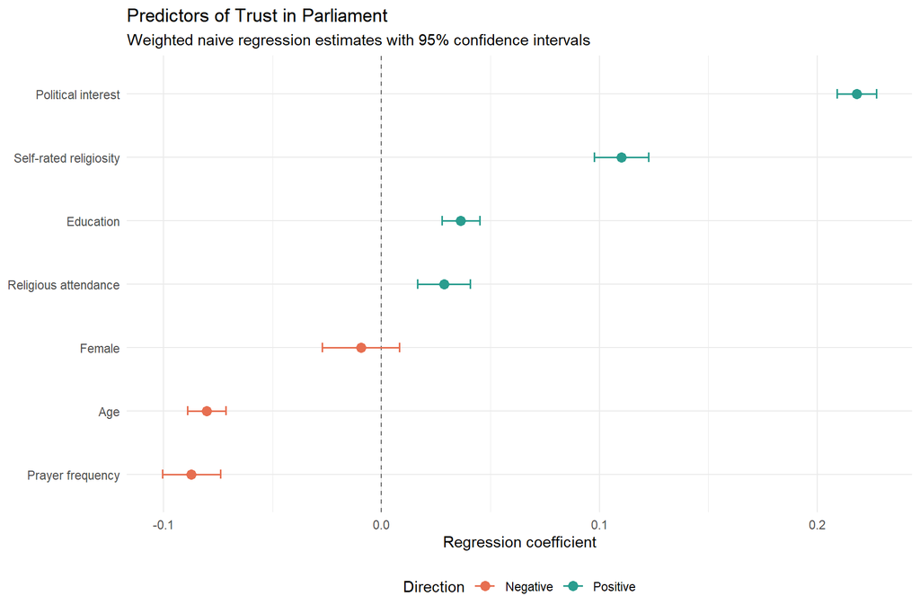

```r
# Create the coefficient plot.
naive_coefficient_plot <- ggplot(
  coefficient_plot_data,
  aes(
    x = variable,
    y = estimate,
    colour = direction
  )
) +
  geom_hline(
    yintercept = 0,
    linetype = "dashed",
    colour = "grey40"
  ) +
  geom_errorbar(
    aes(
      ymin = lower,
      ymax = upper
    ),
    width = 0.15,
    linewidth = 0.7
  ) +
  geom_point(
    size = 3
  ) +
  coord_flip() +
  scale_colour_manual(
    values = c(
      "Positive" = "#2A9D8F",
      "Negative" = "#E76F51"
    )
  ) +
  labs(
    title = "Predictors of Trust in Parliament",
    subtitle = "Weighted naive regression estimates with 95% confidence intervals",
    x = NULL,
    y = "Regression coefficient",
    colour = "Direction"
  ) +
  theme_minimal() +
  theme(
    legend.position = "bottom"
  )

# Display the figure.
print(naive_coefficient_plot)
```

## Calculation and interpretation of the naive regression

The naive regression uses **weighted least squares (WLS) to estimate the regression coefficients**. Following Dunn and Smyth (2018, Chapter 2), we start with one predictor, extend the calculation to several predictors, and then introduce matrices. A small artificial example follows the calculations throughout; the actual ESS results are discussed at the end.

### 1. Start with one predictor: what are we estimating?

Suppose we want to describe trust in parliament using only self-rated religiosity. The simple regression model specifies the expected outcome as:

$$\mu_i=\operatorname{E}(y_i\mid x_i)=\beta_0+\beta_1x_i.$$

Here, $i$ identifies a respondent, $y_i$ is their observed trust score, and $x_i$ is their religiosity score. The expectation $\operatorname{E}(y_i\mid x_i)$, written $\mu_i$, is the average outcome the model expects at that particular value of $x$. The intercept $\beta_0$ gives this expected outcome when $x=0$; the slope $\beta_1$ gives its change when $x$ increases by one unit.

An individual’s observed outcome can differ from this expected value:

$$y_i=\mu_i+\varepsilon_i.$$

The error $\varepsilon_i$ is the individual’s deviation from the true model mean. Thus, $y_i$ is observed and $\mu_i$ is expected; they need not be identical. Since the coefficients are unknown, we must estimate the line.

### 2. Measure how well each possible line fits

Each possible pair of values for $\beta_0$ and $\beta_1$ defines a possible line. For that line, calculate the deviations $y_i-\mu_i$, square them, apply the weights and add them:

$$S(\beta_0,\beta_1)
=\sum_{i=1}^{n}w_i(y_i-\mu_i)^2
=\sum_{i=1}^{n}w_i(y_i-\beta_0-\beta_1x_i)^2.$$

Here,$S$ is the weighted **sum of squared deviations**, $n$ is the number of observations and $w_i>0$ is respondent $i$’s weight. The notation $\sum_{i=1}^{n}$ means “calculate this quantity for every respondent and add the results.” The final expression replaces $\mu_i$ with the line’s equation.

Squaring prevents positive and negative deviations from cancelling: deviations of $+2$ and $-2$ sum to zero, but their squares sum to $8$. Larger weights give an observation’s squared deviation more influence. **Least squares chooses the coefficient values that make** $S$ as small as possible; if every weight equals one, this is ordinary least squares (OLS).

**Numerical example.** Consider three artificial observations with illustrative precision weights:

| Respondent $i$ | Predictor $x_i$ | Outcome $y_i$ | Weight $w_i$ |
| --- | --- | --- | --- |
| 1 | 1 | 2 | 1 |
| 2 | 2 | 2 | 2 |
| 3 | 3 | 5 | 1 |

Try an intercept of zero and a slope of one. The proposed line assigns fitted values of $1$, $2$ and $3$, so its weighted squared error is:

$$S(0,1)=1(2-1)^2+2(2-2)^2+1(5-3)^2=5.$$

The two arguments in $S(0,1)$ are the **proposed** intercept and slope. Each term uses one row of the table: weight multiplied by the squared difference between the observed and proposed value. This evaluates one possible line; we next find the line with the smallest possible total.

### 3. Find the coefficients that minimise S

To find the minimum, examine how $S$ changes when either coefficient changes:

$$\frac{\partial S}{\partial\beta_0}
=-2\sum_{i=1}^{n}w_i(y_i-\beta_0-\beta_1x_i),$$

$$\frac{\partial S}{\partial\beta_1}
=-2\sum_{i=1}^{n}w_ix_i(y_i-\beta_0-\beta_1x_i).$$

The symbol $\partial$ denotes a partial derivative. The first expression describes changing the intercept while keeping the slope fixed; the second describes changing the slope while keeping the intercept fixed. The extra $x_i$ appears because a slope change affects the fitted value in proportion to $x_i$.

At the least-squares minimum, **both derivatives equal zero**. With positive weights and variation in $x$, solving these two equations gives the unique minimum.

*To express the solution, first calculate the weighted means:*

$$\bar{x}_w=\frac{\sum_{i=1}^{n}w_ix_i}{\sum_{i=1}^{n}w_i},
\qquad
\bar{y}_w=\frac{\sum_{i=1}^{n}w_iy_i}{\sum_{i=1}^{n}w_i}.$$

The bars indicate averages and $w$ indicates weighting*. Each numerator adds the weighted values; the denominator is the total weight. If all weights equal one, these are ordinary sample means.

The first zero-derivative condition can be rearranged as:

$$\sum_{i=1}^{n}w_iy_i
=\beta_0\sum_{i=1}^{n}w_i
+\beta_1\sum_{i=1}^{n}w_ix_i.$$

On the left is the weighted total of observed outcomes. On the right, the intercept contributes once for each unit of weight, while the slope multiplies the weighted total of $x$. Dividing both sides by the sum of weights replaces these totals with the weighted means, giving:

$$\hat{\beta}_0=\bar{y}_w-\hat{\beta}_1\bar{x}_w.$$

The hats identify the estimated coefficients. This equation determines the intercept from the slope and weighted means: it positions the fitted line so that it passes through $(\bar{x}_w,\bar{y}_w)$.

Substituting this expression into the second zero-derivative equation gives the slope:

$$\hat{\beta}_1
=\frac{SS_{xy}}{SS_x}
=\frac{\sum_{i=1}^{n}w_i(x_i-\bar{x}_w)y_i}
{\sum_{i=1}^{n}w_i(x_i-\bar{x}_w)^2}.$$

Here, $SS_{xy}$ is the weighted cross-product sum in the numerator and $SS_x$ is the weighted sum of squared deviations of $x$ in the denominator. The numerator is unchanged if $y_i$ is replaced by $y_i-\bar{y}_w$, because the weighted deviations of $x$ sum to zero. The slope therefore compares how $x$ and $y$ vary together with how much $x$ varies.

In practice, calculate the slope first, then insert it into the intercept formula. These two estimates define the line with the smallest weighted squared error (Dunn and Smyth, 2018, pp. 35–37).

**Continuing the example.** The weighted means are:

$$\bar{x}_w=\frac{1\cdot1+2\cdot2+1\cdot3}{1+2+1}=2,
\qquad
\bar{y}_w=\frac{1\cdot2+2\cdot2+1\cdot5}{1+2+1}=2.75.$$

The second respondent contributes twice as much weight as either of the others. Using these means in the slope calculation gives:

$$\begin{aligned}
SS_{xy}&=1(1-2)2+2(2-2)2+1(3-2)5=3,\\
SS_x&=1(1-2)^2+2(2-2)^2+1(3-2)^2=2,\\
\hat{\beta}_1&=3/2=1.5,\\
\hat{\beta}_0&=2.75-1.5\cdot2=-0.25.
\end{aligned}$$

The first two lines calculate the slope’s numerator and denominator from the three observations. Their ratio gives a slope of $1.5$; substituting that slope into the intercept formula gives $-0.25$. The estimated line is therefore $\hat{\mu}_i=-0.25+1.5x_i$.

### 4. Calculate fitted values, residuals and RSS

Now use the estimated coefficients to calculate each fitted value:

$$\hat{\mu}_i=\hat{y}_i=\hat{\beta}_0+\hat{\beta}_1x_i.$$

Both $\hat{\mu}_i$ and $\hat{y}_i$ denote the fitted value: our estimate of the expected outcome at respondent $i$’s value of $x$.

The residual is then:

$$r_i=y_i-\hat{\mu}_i.$$

Here, $r_i$ is observed minus fitted: a positive residual indicates underprediction, and a negative one indicates overprediction. Unlike the unknown error $\varepsilon_i$, it is calculable after fitting.

Putting these final residuals back into the sum-of-squares formula gives:

$$RSS=S(\hat{\beta}_0,\hat{\beta}_1)
=\sum_{i=1}^{n}w_ir_i^2
=\sum_{i=1}^{n}w_i(y_i-\hat{\mu}_i)^2.$$

The residual sum of squares, RSS, is the **smallest value of** $S$, obtained at the estimated coefficients. It measures the total weighted discrepancy remaining between the observations and the fitted line.

**Continuing the example.** Substitute each $x_i$ into the estimated line, subtract the resulting value from $y_i$, and square and weight that residual:

| Respondent | Fitted value $\hat{\mu}_i$ | Residual $r_i$ | Weighted squared residual $w_ir_i^2$ |
| --- | --- | --- | --- |
| 1 | 1.25 | 0.75 | 0.5625 |
| 2 | 2.75 | −0.75 | 1.1250 |
| 3 | 4.25 | 0.75 | 0.5625 |

Adding the last column gives:

$$RSS=0.5625+1.1250+0.5625=2.25.$$

This is smaller than the value $S=5$ obtained for the initial proposed line. It is the minimum reached by selecting the least-squares coefficients.

### 5. Use RSS to estimate the remaining variance

$$\operatorname{Var}(y_i\mid x_i)
=\operatorname{E}\!\left[(y_i-\mu_i)^2\mid x_i\right]
=\frac{\sigma^2}{w_i}.$$

The variance $\operatorname{Var}(y_i\mid x_i)$ is the expected squared deviation around the true mean at a given $x_i$. The unknown $\sigma^2$ is the variance scale; this assumption makes larger weights correspond to smaller error variances. In OLS, all $w_i=1$ and all errors have variance $\sigma^2$. The coefficient formulas do not contain $\sigma^2$, so we can estimate the line before estimating this variance.

We estimate this scale from the fitted residuals:

$$s^2=\frac{RSS}{n-2},
\qquad
s=\sqrt{s^2}.$$

Here, $s^2$ estimates $\sigma^2$, and $s$ is the residual standard error. The denominator $n-2$ is the residual degrees of freedom: two coefficients, the intercept and slope, were estimated from the data. Dividing by $n$ would underestimate the variance because those coefficients were specifically chosen to reduce RSS; the degrees-of-freedom correction makes $s^2$ unbiased under the stated model.

**In the example**, there are three observations and two estimated coefficients:

$$s^2=\frac{2.25}{3-2}=2.25,
\qquad
s=\sqrt{2.25}=1.5.$$

Here, $n=3$ counts the observations; the sum of weights, $4$, is used in the weighted means. Only one residual degree of freedom remains, so this tiny dataset provides little information for estimating the variance.

The residual variance also helps quantify uncertainty in the slope:

$$\operatorname{Var}(\hat{\beta}_1)=\frac{\sigma^2}{SS_x},
\qquad
\operatorname{se}(\hat{\beta}_1)
=\sqrt{\frac{s^2}{SS_x}}.$$

Here, $SS_x$ is the weighted spread of $x$ defined in the slope formula. The first expression describes how slope estimates would vary across repeated samples; replacing $\sigma^2$ with $s^2$ and taking the square root gives the estimated standard error, $\operatorname{se}(\hat{\beta}_1)$. More residual variation makes the slope less precise, while more spread in $x$, at a fixed variance scale, makes it easier to estimate (Dunn and Smyth, 2018, pp. 38–39).

For the example, the slope’s standard error is $\sqrt{2.25/2}\approx1.06$. Thus, the estimated slope of $1.5$ has substantial uncertainty; the t-test below expresses the estimate relative to this uncertainty.

### 6. Extend the calculation to several predictors, still using sums

With $p$ predictors, the expected outcome becomes:

$$\mu_i=\beta_0+\sum_{j=1}^{p}\beta_jx_{ij}
=\beta_0+\beta_1x_{i1}+\cdots+\beta_px_{ip}.$$

Here, $j$ identifies a predictor and $x_{ij}$ is respondent $i$’s value on that predictor. The inner sum adds the predictors’ contributions for **one respondent**. The coefficient $\beta_j$ describes the association with predictor $j$ while holding the other predictors constant.

The quantity to minimise is now:

$$S(\beta_0,\ldots,\beta_p)
=\sum_{i=1}^{n}w_i
\left(y_i-\beta_0-\sum_{j=1}^{p}\beta_jx_{ij}\right)^2.$$

The inner sum over $j$ constructs one respondent’s expected score. The outer sum over $i$ adds the weighted squared deviations across **all respondents**. The principle is unchanged: choose the $p+1$ coefficients that minimise this total, by setting the derivative with respect to each coefficient to zero.

The book also expresses each predictor’s estimated coefficient without matrices:

$$\hat{\beta}_j
=\frac{\sum_{i=1}^{n}w_ix_{ij}^{*}y_i}
{\sum_{i=1}^{n}w_i(x_{ij}^{*})^2}.$$

Here, $x_{ij}^{*}$ is the residual obtained by regressing predictor $j$ on the other predictors and an intercept, using the same weights. For example, to estimate the coefficient of self-rated religiosity, first predict religiosity from attendance, prayer and the controls. Subtract that predicted religiosity score from the observed religiosity score: the remainder is $x_{ij}^{*}$.

The numerator links this remaining part of religiosity to the outcome, and the denominator measures its weighted spread. This explains what “holding the other predictors constant” means. With just one predictor, only the intercept is removed, so $x_i^{*}=x_i-\bar{x}_w$ and the formula becomes the simple-regression slope above. These auxiliary regressions explain the coefficient formula; the fitted regression software obtains all coefficients jointly.

After estimating the coefficients, the fitted values and variance estimate are:

$$\hat{\mu}_i=\hat{\beta}_0+\sum_{j=1}^{p}\hat{\beta}_jx_{ij},
\qquad
s^2=\frac{\sum_{i=1}^{n}w_i(y_i-\hat{\mu}_i)^2}{n-p'}
=\frac{RSS}{n-p'}.$$

Here, $p'=p+1$ counts all estimated coefficients, including the intercept. The fitted-value and RSS calculations work exactly as before; the variance denominator changes because more coefficients were estimated. Our seven predictors give $p=7$, $p'=8$ and $n-8$ residual degrees of freedom (Dunn and Smyth, 2018, pp. 40–43).

### 7. Write the same calculations using matrices

We can now collect the values already introduced into a model matrix and column vectors:

$$\mathbf{X}=
\begin{bmatrix}
1&x_{11}&\cdots&x_{1p}\\
1&x_{21}&\cdots&x_{2p}\\
\vdots&\vdots&\ddots&\vdots\\
1&x_{n1}&\cdots&x_{np}
\end{bmatrix},
\qquad
\boldsymbol{\beta}=
\begin{bmatrix}\beta_0\\\beta_1\\\vdots\\\beta_p\end{bmatrix},
\qquad
\mathbf{y}=
\begin{bmatrix}y_1\\y_2\\\vdots\\y_n\end{bmatrix}.$$

The matrix $\mathbf{X}$ has $n$ respondent rows and $p'$ columns: one for the intercept and one for each predictor. Its first column of ones includes $\beta_0$ for every respondent. The vectors $\boldsymbol{\beta}$ and $\mathbf{y}$ contain the coefficients and observed outcomes.

Matrix multiplication performs the predictor sum for every respondent at once:

$$\boldsymbol{\mu}=\mathbf{X}\boldsymbol{\beta}.$$

Here, $\boldsymbol{\mu}$ is the column of expected values. Its $i$th entry is precisely $\beta_0+\sum_{j=1}^{p}\beta_jx_{ij}$ from the preceding section.

Place the weights on the diagonal of an $n\times n$ matrix, $\mathbf{W}=\operatorname{diag}(w_1,\ldots,w_n)$, with zeros elsewhere. Then:

$$S=(\mathbf{y}-\mathbf{X}\boldsymbol{\beta})^T
\mathbf{W}(\mathbf{y}-\mathbf{X}\boldsymbol{\beta})
=\sum_{i=1}^{n}w_i(y_i-\mu_i)^2.$$

The superscript $T$ means transpose: a column becomes a row. The difference contains all deviations; the multiplication weights their squares and adds them. The result is the same single number $S$ as before.

Setting all coefficient derivatives to zero gives the normal equations:

$$\mathbf{X}^T\mathbf{W}\mathbf{X}\hat{\boldsymbol{\beta}}
=\mathbf{X}^T\mathbf{W}\mathbf{y}.$$

This collects the earlier zero-derivative conditions into one expression. The vector $\hat{\boldsymbol{\beta}}$ contains the estimates satisfying them. Solving gives:

$$\hat{\boldsymbol{\beta}}
=(\mathbf{X}^T\mathbf{W}\mathbf{X})^{-1}
\mathbf{X}^T\mathbf{W}\mathbf{y}.$$

The superscript $-1$ denotes the inverse matrix. The matrix being inverted is $p'\times p'$, or $8\times8$ here; invertibility requires that no column of $\mathbf{X}$ is an exact linear combination of the others. This solves for all coefficients jointly.

**The same three observations in matrix form.** Our example has $n=3$ observations and $p'=2$ coefficients:

$$\mathbf{X}=\begin{bmatrix}1&1\\1&2\\1&3\end{bmatrix},
\qquad
\mathbf{W}=\begin{bmatrix}1&0&0\\0&2&0\\0&0&1\end{bmatrix},
\qquad
\mathbf{y}=\begin{bmatrix}2\\2\\5\end{bmatrix}.$$

The first column of $\mathbf{X}$ represents the intercept and the second contains $x$. The diagonal of $\mathbf{W}$ contains the same three weights used in the sums. The matrix products collect those sums as follows:

$$\mathbf{X}^T\mathbf{W}\mathbf{X}
=\begin{bmatrix}
\sum_iw_i&\sum_iw_ix_i\\
\sum_iw_ix_i&\sum_iw_ix_i^2
\end{bmatrix}
=\begin{bmatrix}4&8\\8&18\end{bmatrix},$$

$$\mathbf{X}^T\mathbf{W}\mathbf{y}
=\begin{bmatrix}\sum_iw_iy_i\\\sum_iw_ix_iy_i\end{bmatrix}
=\begin{bmatrix}11\\25\end{bmatrix}.$$

Every entry is a weighted sum: for example, $\sum_iw_ix_i=1\cdot1+2\cdot2+1\cdot3=8$. The first matrix collects weighted sums involving the predictor; the second collects weighted sums linking it and the intercept to the outcome.

The normal equations therefore say:

$$\begin{bmatrix}4&8\\8&18\end{bmatrix}
\begin{bmatrix}\hat{\beta}_0\\\hat{\beta}_1\end{bmatrix}
=\begin{bmatrix}11\\25\end{bmatrix}
\quad\Longleftrightarrow\quad
\begin{cases}
4\hat{\beta}_0+8\hat{\beta}_1=11,\\
8\hat{\beta}_0+18\hat{\beta}_1=25.
\end{cases}$$

Multiplying the first equation by two and subtracting it from the second leaves $2\hat{\beta}_1=3$, so $\hat{\beta}_1=1.5$ and then $\hat{\beta}_0=-0.25$. These are exactly the coefficients calculated earlier using sums. Matrix notation packages the same equations so they can be solved conveniently for many predictors.

The corresponding estimated coefficient covariance matrix is:

$$\widehat{\operatorname{Var}}(\hat{\boldsymbol{\beta}})
=s^2(\mathbf{X}^T\mathbf{W}\mathbf{X})^{-1}.$$

The diagonal entries are individual coefficient variances: the first belongs to the intercept, the second to $\beta_1$, and so on. Off-diagonal entries describe how estimates vary together across repeated samples. For each coefficient, take the square root of its estimated variance:

$$\operatorname{se}(\hat{\beta}_j)
=\sqrt{\widehat{\operatorname{Var}}(\hat{\beta}_j)}.$$

The expression under the square root is the corresponding diagonal entry of the estimated covariance matrix. Taking its square root expresses uncertainty in the same units as the coefficient. This generalises the earlier slope-standard-error calculation (Dunn and Smyth, 2018, pp. 43–47).

### 8. Use a coefficient’s standard error in a t-test

To test whether a coefficient equals a specified value, calculate:

$$H_0:\beta_j=\beta_j^0,
\qquad
t_j=\frac{\hat{\beta}_j-\beta_j^0}
{\operatorname{se}(\hat{\beta}_j)}.$$

Here, $H_0$ is the null hypothesis and $\beta_j^0$ is its proposed coefficient value, usually zero; the superscript labels that reference value. The numerator is the estimate’s distance from the proposed value, and the denominator is its standard error. Thus, $t_j$ expresses that distance in standard-error units.

For a two-sided test, a larger absolute $t_j$ provides stronger evidence against $H_0$. Under the null, independent normal errors and the stated WLS variance assumption, its reference distribution is Student’s $t$ with $n-p'$ degrees of freedom. The test concerns this predictor’s coefficient **after accounting for the other predictors** (Dunn and Smyth, 2018, pp. 53–54).

In the example, testing a zero slope gives:

$$t_1=\frac{1.5-0}{\sqrt{2.25/2}}\approx1.41.$$

The slope estimate is about $1.41$ standard errors away from zero. The zero is the hypothesised reference value, while $1.5$ is the estimate obtained from the data; testing the null does not set the fitted coefficient to zero.

### 9. Decompose variation to assess overall fit

An intercept-only model predicts the same weighted mean $\bar{y}_w$ for everyone. To assess what the predictors add, decompose each observation’s deviation from that mean:

$$y_i-\bar{y}_w
=(\hat{\mu}_i-\bar{y}_w)+(y_i-\hat{\mu}_i).$$

The left side is the observed deviation from the baseline. The first term on the right is the deviation accounted for by the fitted model; the second is the residual $r_i$. This separates each observation’s total deviation into fitted and remaining parts.

Square, weight and sum these deviations to obtain:

$$\begin{aligned}
SST&=\sum_{i=1}^{n}w_i(y_i-\bar{y}_w)^2,\\
SS_{\mathrm{Reg}}&=\sum_{i=1}^{n}w_i(\hat{\mu}_i-\bar{y}_w)^2,\\
RSS&=\sum_{i=1}^{n}w_i(y_i-\hat{\mu}_i)^2.
\end{aligned}$$

Here, $SST$ measures total weighted variation around the mean, $SS_{\mathrm{Reg}}$ measures the part accounted for by the regression, and RSS measures the remaining variation around the fitted values. These are sums of squares, not yet variances.

Squaring a sum normally creates a cross-product term. For least squares with an intercept and the same weights throughout, the zero-derivative conditions ensure:

$$\sum_{i=1}^{n}w_i(\hat{\mu}_i-\bar{y}_w)r_i=0,
\qquad
SST=SS_{\mathrm{Reg}}+RSS.$$

The first equality says that the weighted cross-products of fitted deviations and residuals cancel when added across observations. Consequently, total variation splits into the two sums of squares in the second equality. This is the basis of regression analysis of variance, or ANOVA (Dunn and Smyth, 2018, p. 58).

**Continuing the example**, the weighted mean is $2.75$, so:

$$\begin{aligned}
SST&=1(2-2.75)^2+2(2-2.75)^2+1(5-2.75)^2=6.75,\\
SS_{\mathrm{Reg}}&=1(1.25-2.75)^2+2(2.75-2.75)^2+1(4.25-2.75)^2=4.50,\\
RSS&=2.25.
\end{aligned}$$

The first line compares the observed outcomes with their weighted mean. The second compares the fitted values with that same mean. The remaining discrepancy is the RSS already calculated, and the identity is verified: $6.75=4.50+2.25$.

### 10. The F-test: do the predictors jointly improve the model?

The overall null hypothesis is:

$$H_0:\beta_1=\beta_2=\cdots=\beta_p=0.$$

Here, all $p$ predictor coefficients are assumed to be zero, while the intercept is still estimated. Under this hypothesis, the predictors add nothing beyond predicting the weighted mean.

Before comparing the explained and remaining variation, divide their sums of squares by their degrees of freedom:

$$MS_{\mathrm{Reg}}=\frac{SS_{\mathrm{Reg}}}{p},
\qquad
MSE=\frac{RSS}{n-p'}=s^2.$$

The abbreviations mean regression mean square and mean square error. A mean square is a sum of squares divided by its degrees of freedom. The residual quantity is exactly the variance estimate derived earlier.

The overall test compares these two mean squares:

$$F=\frac{MS_{\mathrm{Reg}}}{MSE}
=\frac{SS_{\mathrm{Reg}}/p}{RSS/(n-p')}.$$

The numerator measures regression variation per predictor; the denominator measures the remaining variation per residual degree of freedom. A large ratio provides evidence that the predictors jointly improve on the intercept-only model. Under $H_0$ and the normal WLS assumptions, the reference distribution has $p$ and $n-p'$ degrees of freedom. Its p-value is the probability of obtaining an F-statistic at least this large under the null (Dunn and Smyth, 2018, pp. 58–59).

In the formulas, $p$ counts predictors; in a reported p-value, it denotes the test probability. A significant overall test indicates evidence that at least one predictor coefficient differs from zero, while the individual t-tests examine which coefficients show evidence of a difference.

For our example, $p=1$, $p'=2$ and $n=3$:

$$F=\frac{4.50/1}{2.25/(3-2)}=2.$$

This gives $F(1,1)=2$ and $p\approx.392$ under the stated assumptions, providing little evidence against the null. With one predictor, $F=t_1^2$: the overall F-test and the slope’s two-sided t-test address the same hypothesis.

### 11. R-squared: how much variation does the model account for?

The coefficient of determination is:

$$R^2=\frac{SS_{\mathrm{Reg}}}{SST}
=1-\frac{RSS}{SST}.$$

The first fraction divides the regression sum of squares by the total sum of squares. The second expression gives the same answer by subtracting the unexplained proportion from one, using the ANOVA identity above. With an intercept and nonzero total variation, the fitted model’s $R^2$ lies between zero and one.

In the example:

$$R^2=\frac{4.50}{6.75}=1-\frac{2.25}{6.75}\approx.667.$$

The fitted line accounts for about 66.7% of the weighted variation in these three outcomes. The F-test was nevertheless not significant: a large explained proportion in a very small sample does not by itself provide strong evidence of a population association.

Adding predictors cannot lower $R^2$ when the observations and weights remain the same, even when the improvement is negligible. Adjusted R-squared therefore accounts for the number of estimated coefficients:

$$\bar{R}^2
=1-\frac{RSS/(n-p')}{SST/(n-1)}
=1-(1-R^2)\frac{n-1}{n-p'}.$$

Here, $\bar{R}^2$ is adjusted R-squared. It compares the residual mean square with the total sum of squares divided by its $n-1$ degrees of freedom. Adding a predictor reduces the residual degrees of freedom; unless RSS falls enough, adjusted R-squared decreases. Unlike ordinary $R^2$, it can be negative.

For the three-observation example:

$$\bar{R}^2=1-\frac{2.25/(3-2)}{6.75/(3-1)}\approx.333.$$

The adjustment is large because two coefficients were estimated from only three observations. This contrasts with the much smaller adjustment in our large ESS sample below.

The connection to the F-test follows by substituting $SS_{\mathrm{Reg}}=R^2SST$ and $RSS=(1-R^2)SST$ into the F formula:

$$F=\frac{R^2/p}{(1-R^2)/(n-p')}.$$

The common $SST$ cancels, leaving a relationship between $F$, $R^2$, the sample size and the number of coefficients. This shows why a modest explained proportion can still produce a highly significant F-test in a large sample (Dunn and Smyth, 2018, pp. 59–60).

### Interpretation of the results

The weighted naive regression includes 47,217 respondents, while 2,899 observations were excluded because of missing values. The model contains seven predictors and an intercept, giving eight estimated coefficients and $47{,}217-8=47{,}209$ residual degrees of freedom. The reported fit statistics are:

$$F(7,47{,}209)=474.0,\quad p<.001,
\qquad
R^2=.0657,\quad\bar{R}^2=.0655.$$

The numbers in parentheses after $F$ are its numerator and denominator degrees of freedom. The statistically significant F-test indicates that the predictors jointly improve prediction compared with an intercept-only model, under the naive model’s assumptions. The model accounts for approximately **6.6% of the weighted variation in standardised trust in parliament**. Adjusted $R^2$ is very close to the unadjusted value because seven predictors are few relative to the sample size. Thus, the model is statistically significant, although its explained proportion of variation is modest.

| Predictor | Estimated coefficient | Reported p-value |
| --- | --- | --- |
| Self-rated religiosity | 0.110 | < .001 |
| Religious attendance | 0.029 | < .001 |
| Prayer frequency | −0.087 | < .001 |
| Age | −0.080 | < .001 |
| Gender: women relative to men | −0.009 | .298 |
| Education | 0.036 | < .001 |
| Political interest | 0.218 | < .001 |

Political interest has the strongest positive conditional association with trust in parliament among the standardised predictors ($\hat{\beta}=.218$, $p<.001$). Because both variables are standardised, a one-standard-deviation increase in political interest is associated with an estimated 0.218-standard-deviation increase in trust, holding the other predictors constant. Regression coefficients describe the association of each predictor after adjustment for the remaining variables (Dunn and Smyth, 2018, pp. 52–53).

Self-rated religiosity also has a positive association with trust ($\hat{\beta}=.110$, $p<.001$), while religious attendance has a smaller positive coefficient ($\hat{\beta}=.029$, $p<.001$). Thus, respondents who describe themselves as more religious or attend religious services more frequently tend to report somewhat greater trust, conditional on the other predictors.

Prayer frequency has a negative conditional association with trust ($\hat{\beta}=-.087$, $p<.001$). This does not necessarily imply that people who pray more frequently generally have lower trust. The coefficient represents the association of prayer frequency with trust after holding self-rated religiosity, religious attendance and the control variables constant. The distinction between a predictor’s conditional coefficient and its unadjusted association is important when predictors are correlated (Dunn and Smyth, 2018, pp. 52–53).

Age is negatively associated with trust ($\hat{\beta}=-.080$, $p<.001$), whereas education has a small positive association ($\hat{\beta}=.036$, $p<.001$). These coefficients represent changes in trust in standard-deviation units for a one-standard-deviation increase in each predictor, holding the other variables constant.

Gender is not statistically significant ($\hat{\beta}=-.009$, $p=.298$). Because gender was coded as 0 for men and 1 for women, the coefficient represents the estimated difference between women and men. The result provides no clear evidence of a gender difference after controlling for the other predictors. Coefficients of binary variables describe differences relative to their reference category while holding other predictors constant (Dunn and Smyth, 2018, p. 52).

These results provide a baseline for the multilevel analysis. The reported tests and standard errors are conventional model-based results that do not account for regional and country clustering. The subsequent multilevel models explicitly represent group-level dependence, with variance components estimated using REML and fixed-effect coefficients obtained through generalised least squares under the estimated covariance structure ([Bates et al., 2015](https://lme4.github.io/lme4/articles/lmer.pdf)).

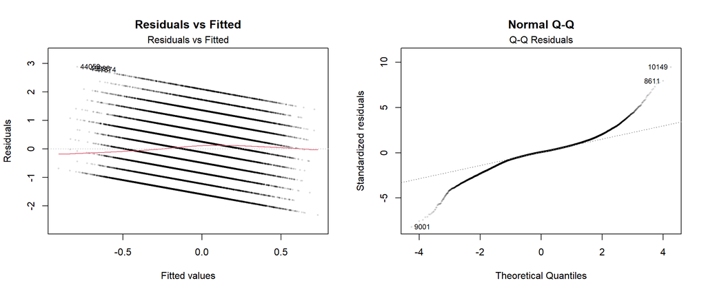

```r
############################################################
# REGRESSION DIAGNOSTIC PLOTS
############################################################

# Display the two diagnostic plots next to each other.
par(
  mfrow = c(1, 2)
)

# Plot residuals against fitted values.
plot(
  lm_mod_z,
  which = 1,
  pch = 16,
  cex = 0.4,
  col = rgb(0, 0, 0, 0.15),
  main = "Residuals vs Fitted"
)

# Create the normal Q-Q plot of standardised residuals.
plot(
  lm_mod_z,
  which = 2,
  pch = 16,
  cex = 0.4,
  col = rgb(0, 0, 0, 0.15),
  main = "Normal Q-Q"
)
```

```r
# Restore the default plotting layout.
par(
  mfrow = c(1, 1)
)
```

### Interpretation of the regression diagnostic plots

The **residuals-versus-fitted plot** compares the values predicted by the regression with the residuals:

$$e_i=y_i-\hat{y}_i.$$

It is used to examine whether the residuals are distributed randomly around zero and whether their spread remains reasonably similar across the range of predicted values. In a well-fitting linear model, the points should form an approximately random horizontal cloud around zero, while the red smoothing line should remain close to the horizontal zero line.

In the present model, the residuals show considerable variation around zero, meaning that respondents with similar predicted levels of trust may still report substantially different actual trust scores. The red line is relatively close to zero but displays some curvature, indicating that a small systematic pattern remains unexplained. The parallel diagonal bands mainly occur because trust in parliament was originally measured using a limited number of integer values from 0 to 10. Consequently, respondents with the same original trust score form similar diagonal lines after standardisation.

The **normal Q-Q plot** compares the observed standardised residuals with the values expected under a normal distribution. If the residuals were approximately normally distributed, the observations would follow the diagonal reference line. Departures from this line indicate differences between the observed residual distribution and a theoretical normal distribution.

The residuals in the centre of the Q-Q plot remain relatively close to the reference line. However, substantial deviations appear in both tails. The lower tail falls below the line, while the upper tail rises above it, indicating more extreme residuals than would be expected under normality. Observations 9001, 8611 and 10149 are especially extreme and should be regarded as outliers. These respondents reported trust scores that differ strongly from the values predicted by their religiosity and control variables. However, extreme residuals do not automatically mean that these observations are incorrect and they should not be removed without substantive justification.

Overall, the diagnostic plots show that the naive regression captures the central pattern reasonably well but leaves considerable individual variation unexplained and does not fully satisfy the normal-residual assumption, particularly in the tails. This supports treating the naive regression as a baseline model. The primary reason for proceeding to multilevel modelling, however, is the hierarchical structure of the ESS data: respondents are nested within regions and countries. The regional null model and its ICC can determine whether part of the remaining variation is systematically associated with regional membership (Dunn and Smyth, 2018, pp. 97 and 101–105; Szeitl, *MLM 1*).

# Multilevel modelling

## What is a multilevel model?

A multilevel model is used when observations are organised into groups rather than assuming that they are completely independent. In the present analysis, respondents constitute Level 1 and ESS regions constitute Level 2:

- Level 1: respondents;
- Level 2: regions.

Respondents living in the same region may be more similar to one another than respondents from different regions because they share a common political, economic and institutional context. A multilevel model represents this hierarchical structure by separating individual-level variation from variation between regions.

A two-level random-intercept model can be written as:

$$Y_{ij}
=
\beta_{0j}
+
\sum_{q=1}^{Q}\beta_q x_{qij}
+
r_{ij},$$

where the regional intercept is:

$$\beta_{0j}
=
\gamma_{00}+u_{0j}.$$

Substituting the second equation into the first gives the combined multilevel model:

$$Y_{ij}
=
\gamma_{00}
+
\sum_{q=1}^{Q}\beta_q x_{qij}
+
u_{0j}
+
r_{ij}.$$

In these equations:

- $Y_{ij}$ is the outcome of respondent $i$ in region $j$;
- $i$ identifies respondents;
- $j$ identifies regions;
- $x_{qij}$ is respondent $i$’s value on predictor $q$;
- $Q$ is the number of predictors;
- $\gamma_{00}$ is the overall fixed intercept;
- $\beta_q$ is the fixed coefficient of predictor $q$;
- $u_{0j}$ is region $j$’s deviation from the overall intercept;
- $\beta_{0j}=\gamma_{00}+u_{0j}$ is the intercept specific to region $j$;
- $r_{ij}$ is the individual-level residual.

## Preparing the grouping variables

The country and region variables must be represented as categorical grouping variables. Because the same region code could occur in more than one country, a new identifier is created by combining country and region. This ensures that every regional group is unique within the complete cross-national dataset.

```r
############################################################
# PREPARE THE GROUPING VARIABLES
############################################################

# Convert country and region into categorical variables.
# Create a region identifier that is unique within
# the complete cross-national ESS dataset.
ess_mlm <- ess_mlm %>%
  mutate(
    cntry = factor(cntry),
    region = factor(region),
    region_id = interaction(
      cntry,
      region,
      drop = TRUE
    )
  )

# Display the number of countries.
nlevels(ess_mlm$cntry)
```

```
## [1] 30
```

```r
# Display the number of unique country-region groups.
nlevels(ess_mlm$region_id)
```

```
## [1] 328
```

```r
# Display the distribution of regional sample sizes.
summary(
  as.numeric(
    table(ess_mlm$region_id)
  )
)
```

```
##    Min. 1st Qu.  Median    Mean 3rd Qu.    Max.
##     1.0    55.0   103.0   152.8   187.5  1609.0
```

In the `region_id` variable, a code such as `HU.REGION1` is treated as a different group from `DE.REGION1`. This prevents identically coded regions in different countries from being incorrectly combined. The regional sample-size summary also shows whether the regions contain sufficient observations and whether their sample sizes differ substantially.

## What is a null model?

A null model, also called an unconditional or empty model, contains no explanatory variables. It includes only an overall intercept and a random regional intercept. Its purpose is to determine how its total variation is divided between respondents and regions. It also provides a baseline for subsequent models containing religiosity and the control variables (Szeitl, *MLM 1*, PDF pp. 54–56).

The regional null model is:

$$Y_{ij}=\gamma_{00}+u_{0j}+r_{ij},$$

where:

- $Y_{ij}$ is the standardised trust score of respondent $i$ in region $j$;
- $\gamma_{00}$ is the overall mean intercept;
- $u_{0j}$ is the deviation of region $j$ from the overall intercept;
- $r_{ij}$ is the individual-level residual.

## Estimating the regional null model

```r
############################################################
# REGIONAL NULL MODEL
############################################################

# Estimate an unconditional regional model
# without explanatory variables.
m0_region <- lme4::lmer(
  trstprl_z ~
    1 +
    (1 | region_id),
  data = ess_mlm,
  weights = weight,
  REML = TRUE,
  na.action = na.exclude
)

# Display the null-model results.
summary(m0_region)
```

```
## Linear mixed model fit by REML ['lmerMod']
## Formula: trstprl_z ~ 1 + (1 | region_id)
##    Data: ess_mlm
## Weights: weight
##
## REML criterion at convergence: 169904.2
##
## Scaled residuals:
##     Min      1Q  Median      3Q     Max
## -7.5261 -0.4439  0.0369  0.4567  7.4746
##
## Random effects:
##  Groups    Name        Variance Std.Dev.
##  region_id (Intercept) 0.2094   0.4577
##  Residual              0.7878   0.8876
## Number of obs: 49118, groups:  region_id, 328
##
## Fixed effects:
##             Estimate Std. Error t value
## (Intercept) -0.08527    0.02674  -3.189
```

In the formula, `1` represents the overall fixed intercept, while `(1 | region_id)` introduces a random intercept for every region. The output separates the variance into a regional random-intercept variance and an individual-level residual variance.

the ICC is $0.2094/(0.2094+0.7878)\approx0.210$, meaning that approximately 21% of the variation in trust is associated with regional differences, supporting the use of multilevel modelling (we will talk in more detail about the ICC in the next phase of the analysis).

### Regional random-intercept model

The regional random-intercept model extends the null model by including the three religiosity variables and the individual-level control variables. It estimates their average associations with trust in parliament while allowing the expected level of trust to differ across regions.

### Level 1: respondents within regions

At the individual level, the model is:

$$\begin{aligned}
Y_{ij}={}&
\beta_{0j}
+\beta_1\operatorname{rlgdgr}_{ij}
+\beta_2\operatorname{rlgatnd}_{ij}
+\beta_3\operatorname{pray}_{ij}\\
&+\beta_4\operatorname{age}_{ij}
+\beta_5\operatorname{female}_{ij}
+\beta_6\operatorname{education}_{ij}
+\beta_7\operatorname{polintr}_{ij}
+r_{ij}.
\end{aligned}$$

Here, $\beta_{0j}$ is the intercept for region $j$. Unlike an ordinary regression, this intercept is not required to be identical in every region.

### Level 2: regional intercepts

The region-specific intercept is:

$$\beta_{0j}
=
\beta_0+u_{0j}.$$

The term $\beta_0$ is the overall fixed intercept, while $u_{0j}$ is the random deviation of region $j$ from that overall intercept. For example, $u_{0j}>0$ means that region $j$ has a higher expected level of trust than the overall average, whereas $u_{0j}<0$ means that it has a lower expected level.

Substituting the regional-intercept equation into the individual-level equation produces the combined model:

$$\begin{aligned}
Y_{ij}={}&
\beta_0
+\beta_1\operatorname{rlgdgr}_{ij}
+\beta_2\operatorname{rlgatnd}_{ij}
+\beta_3\operatorname{pray}_{ij}\\
&+\beta_4\operatorname{age}_{ij}
+\beta_5\operatorname{female}_{ij}
+\beta_6\operatorname{education}_{ij}
+\beta_7\operatorname{polintr}_{ij}\\
&+u_{0j}+r_{ij}.
\end{aligned}$$

### where

- $Y_{ij}$ is the standardised trust score of respondent $i$ in region $j$.
- The subscript $i$ identifies respondents.
- The subscript $j$ identifies regions.
- $\beta_0$ is the overall fixed intercept.
- $\beta_1,\ldots,\beta_7$ are the fixed regression coefficients.
- $u_{0j}$ is the random deviation of region $j$ from the overall intercept.
- $r_{ij}$ is the remaining individual-level residual.
- The $+$ signs indicate that the separate model components are added together to produce the predicted trust score.
- $\operatorname{rlgdgr}_{ij}$ and the other named terms represent respondent $i$’s values on the predictors in region $j$.
- The word “fixed” means that one average coefficient is estimated for the complete sample.
- The word “random” means that the regional intercept is allowed to vary across regions.

The model is called a **random-intercept model** because the model allows for the intercept $\beta_{0j}$ to vary across regions. The predictor coefficients $\beta_1,\ldots,\beta_7$ are currently assumed to be the same in every region. In the R formula, this varying regional intercept is represented by `(1 | region_id)` (Szeitl, *MLM 1*, PDF pp. 57–58; Szeitl, *MLM 2*, PDF pp. 34–35).

```r
############################################################
# REGIONAL RANDOM-INTERCEPT MODEL
############################################################

# Estimate the regional random-intercept model.
m1_region <- lme4::lmer(
  trstprl_z ~
    rlgdgr_z +
    rlgatnd_rec_z +
    pray_rec_z +
    agea_rec_z +
    gndr_rec +
    eisced_rec_z +
    polintr_rec_z +
    (1 | region_id),
  data = ess_mlm,
  weights = weight,
  REML = TRUE,
  na.action = na.exclude
)

# Display the model results.
summary(m1_region)
```

```
## Linear mixed model fit by REML ['lmerMod']
## Formula: trstprl_z ~ rlgdgr_z + rlgatnd_rec_z + pray_rec_z + agea_rec_z +
##     gndr_rec + eisced_rec_z + polintr_rec_z + (1 | region_id)
##    Data: ess_mlm
## Weights: weight
##
## REML criterion at convergence: 160261.5
##
## Scaled residuals:
##     Min      1Q  Median      3Q     Max
## -9.0379 -0.4402  0.0354  0.4506  9.3356
##
## Random effects:
##  Groups    Name        Variance Std.Dev.
##  region_id (Intercept) 0.1938   0.4402
##  Residual              0.7379   0.8590
## Number of obs: 47217, groups:  region_id, 328
##
## Fixed effects:
##                Estimate Std. Error t value
## (Intercept)   -0.063751   0.026170  -2.436
## rlgdgr_z       0.089643   0.006138  14.605
## rlgatnd_rec_z  0.069164   0.006081  11.375
## pray_rec_z    -0.046278   0.006494  -7.126
## agea_rec_z    -0.072855   0.004202 -17.339
## gndr_rec      -0.014018   0.008521  -1.645
## eisced_rec_z   0.076346   0.004262  17.914
## polintr_rec_z  0.170699   0.004508  37.864
##
## Correlation of Fixed Effects:
##             (Intr) rlgdg_ rlgt__ pry_r_ ag_rc_ gndr_r escd__
## rlgdgr_z     0.006
## rlgtnd_rc_z  0.000 -0.329
## pray_rec_z   0.024 -0.467 -0.352
## agea_rec_z   0.021 -0.072  0.013 -0.074
## gndr_rec    -0.173 -0.033  0.029 -0.115 -0.039
## eisced_rc_z  0.030  0.038 -0.017  0.027  0.163 -0.085
## polntr_rc_z -0.030  0.010 -0.007 -0.009 -0.170  0.168 -0.285
```

## Interpretation of the regional random-intercept model

In the output we can see that the political interest has the strongest positive association with trust in parliament ($\hat{\beta}=0.171$, $t=37.86$). A one-standard-deviation increase in political interest is associated with an estimated 0.171-standard-deviation increase in trust, holding the other predictors and regional differences constant.

Self-rated religiosity ($\hat{\beta}=0.090$, $t=14.61$), religious attendance ($\hat{\beta}=0.069$, $t=11.38$) and education ($\hat{\beta}=0.076$, $t=17.91$) also have positive conditional associations with trust. Prayer frequency has a negative association ($\hat{\beta}=-0.046$, $t=-7.13$), meaning that more frequent prayer is associated with lower trust after controlling for the other dimensions of religiosity and the control variables.

Age has a negative coefficient ($\hat{\beta}=-0.073$, $t=-17.34$), indicating lower predicted trust among older respondents after adjustment for the other variables. The gender coefficient is small ($\hat{\beta}=-0.014$, $t=-1.65$), providing no clear evidence of a difference between women and men. The other coefficients have large absolute $t$-values and therefore show substantially stronger evidence of associations with trust.

The remaining between-region variance is $0.1938$, corresponding to a regional-intercept standard deviation of $0.4402$. The within-region residual variance is $0.7379$, with a standard deviation of $0.8590$. Thus, even after including the predictors, considerable variation remains both between regions and between respondents within the same region (Szeitl, *MLM 2*, PDF pp. 36 and 41).

## Conditional intraclass correlation coefficient

The intraclass correlation coefficient (ICC) measures the extent to which respondents from the same region resemble one another. It can be interpreted in two equivalent ways:

1. the proportion of the remaining variance in trust associated with differences between regions;
2. the expected correlation between the trust scores of two randomly selected respondents from the same region.

For a random-intercept model, the ICC is calculated as:

$$ICC
=
\frac{\tau_{00}}
{\tau_{00}+\sigma^2},$$

where:

- $\tau_{00}$ is the between-region random-intercept variance;
- $\sigma^2$ is the within-region individual residual variance;
- $\tau_{00}+\sigma^2$ is the total remaining variance.

In the present model, the between-region variance is $0.1938$ and the individual residual variance is $0.7379$. The total remaining variance is therefore:

$$\tau_{00}+\sigma^2
=
0.1938+0.7379
=
0.9317.$$

The conditional regional ICC is:

$$ICC
=
\frac{0.1938}{0.9317}
\approx0.208.$$

This means that 20.8% of the remaining unexplained variance in trust is therefore associated with differences between regions. The remaining 79.2% is associated with differences between respondents within regions:

$$1-0.208=0.792.$$

An ICC of zero would indicate no remaining differences between regions, while values closer to one would indicate stronger regional clustering. The obtained ICC of $0.208$ shows that respondents from the same region remain meaningfully similar even after controlling for religiosity, age, gender, education and political interest (Szeitl, *MLM 1*, PDF p. 55; Szeitl, *MLM 2*, PDF pp. 42–44).

The null model produced an ICC of approximately $0.210$, while the conditional model produces an ICC of approximately $0.208$. The small difference indicates that the individual-level predictors explain some variation in trust but do not substantially eliminate the regional clustering. This supports the continued use of a multilevel model.

# Model-fit and variance statistics

Several statistics are calculated to describe the fit and variance structure of the regional random-intercept model. AIC and BIC balance model fit against model complexity, while the log-likelihood indicates how well the estimated model corresponds to the observed data. These measures are interpreted comparatively: lower AIC and BIC values indicate better relative fit, while a higher log-likelihood indicates better fit.

The Akaike Information Criterion is:

$$AIC=-2\ell+2k,$$

and the Bayesian Information Criterion is:

$$BIC=-2\ell+k\log(n),$$
Here, $\ell$ is the model log-likelihood, which measures how compatible the observed data are with the estimated model; larger, or less negative, values indicate better fit. The term $k$ is the total number of estimated model parameters, including fixed-effect coefficients and variance parameters, while $n$ is the number of observations used to estimate the model. Both AIC and BIC penalise the inclusion of additional parameters, preventing more complex models from appearing better simply because they contain more terms. BIC applies a stronger complexity penalty when the sample size is large. Consequently, lower AIC and BIC values indicate a preferable balance between model fit and complexity, but the values have meaning only when compared across suitable models fitted to the same data (Dunn and Smyth, 2018, pp. 69–71).

```r
############################################################
# MODEL-FIT STATISTICS USED IN THE COURSE NOTES
############################################################

# Display the Akaike Information Criterion.
AIC(m1_region)
```

```
## [1] 160281.5
```

```r
# Display the Bayesian Information Criterion.
BIC(m1_region)
```

```
## [1] 160369.1
```

```r
# Display the restricted log-likelihood.
logLik(
  m1_region,
  REML = TRUE
)
```

```
## 'log Lik.' -80130.76 (df=10)
```

```r
# Display the REML criterion:
# -2 multiplied by the restricted log-likelihood.
lme4::REMLcrit(m1_region)
```

```
## [1] 160261.5
```

```r
# Calculate the conditional regional ICC after including
# the explanatory and control variables.
icc_m1_region <- performance::icc(m1_region)

# Display the conditional ICC.
icc_m1_region
```

```
## # Intraclass Correlation Coefficient
##
##     Adjusted ICC: 0.208
##   Unadjusted ICC: 0.197
```

# Regional random-intercept estimates

The random-intercept model estimates a separate adjusted intercept for every region:

$$\hat{\beta}_{0j}
=
\hat{\beta}_0+\hat{u}_{0j},$$

where $\hat{\beta}_0$ is the overall intercept and $\hat{u}_{0j}$ is the estimated deviation of region $j$ from that intercept. A positive $\hat{u}_{0j}$ indicates higher predicted trust than the overall adjusted level, while a negative value indicates lower predicted trust. These differences are adjusted for religiosity, age, gender, education and political interest.

The approximate 95% conditional interval around each regional deviation is:

$$\hat{u}_{0j}
\pm
1.96\times
\operatorname{SE}(\hat{u}_{0j}).$$
(Szeitl, *MLM 2*, PDF pp. 34–36 and 41).

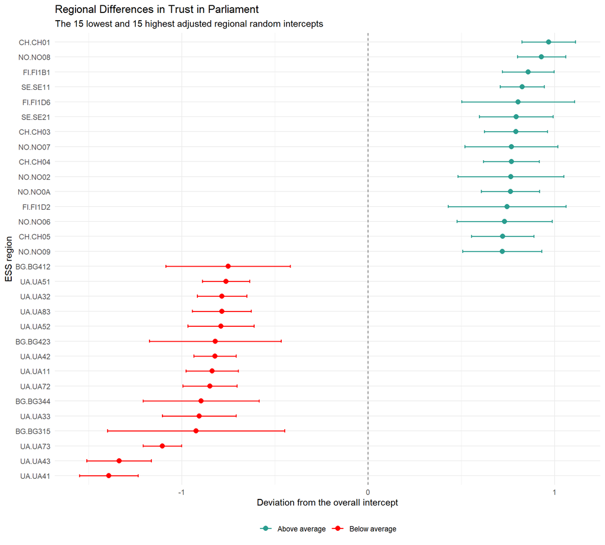

```r
############################################################
# VISUALISE THE REGIONAL RANDOM INTERCEPTS
############################################################

# Extract the regional random-intercept estimates
# and their conditional standard errors.
region_effects <- as.data.frame(
  ranef(
    m1_region,
    condVar = TRUE
  )
) %>%
  filter(
    grpvar == "region_id",
    term == "(Intercept)"
  ) %>%
  transmute(
    region = as.character(grp),
    estimate = condval,
    standard_error = condsd,
    lower = estimate - 1.96 * standard_error,
    upper = estimate + 1.96 * standard_error
  )

# Select the 15 lowest and 15 highest regional estimates.
extreme_regions <- bind_rows(
  region_effects %>%
    slice_min(
      estimate,
      n = 15,
      with_ties = FALSE
    ),

  region_effects %>%
    slice_max(
      estimate,
      n = 15,
      with_ties = FALSE
    )
) %>%
  distinct(
    region,
    .keep_all = TRUE
  ) %>%
  mutate(
    direction = ifelse(
      estimate >= 0,
      "Above average",
      "Below average"
    ),

    region = reorder(
      region,
      estimate
    )
  )

# Plot the regional random-intercept estimates
# with approximate 95% conditional intervals.
region_random_plot <- ggplot(
  extreme_regions,
  aes(
    x = region,
    y = estimate,
    colour = direction
  )
) +
  geom_hline(
    yintercept = 0,
    linetype = "dashed",
    colour = "grey40"
  ) +
  geom_errorbar(
    aes(
      ymin = lower,
      ymax = upper
    ),
    width = 0.20,
    linewidth = 0.6
  ) +
  geom_point(
    size = 2.5
  ) +
  coord_flip() +
  scale_colour_manual(
    values = c(
      "Above average" = "#2A9D8F",
      "Below average" = "#FF0000"
    )
  ) +
  labs(
    title = "Regional Differences in Trust in Parliament",
    subtitle = "The 15 lowest and 15 highest adjusted regional random intercepts",
    x = "ESS region",
    y = "Deviation from the overall intercept",
    colour = NULL
  ) +
  theme_minimal() +
  theme(
    legend.position = "bottom"
  )

# Display the figure.
print(region_random_plot)
```

# Regional random-slope model

## What is a random slope?

The random-intercept model allows regions to have different expected levels of trust, but assumes that the association between self-rated religiosity and trust is identical in every region. This assumption can be relaxed with a random-slope model.

In the random-slope model, both the intercept and the coefficient of self-rated religiosity may vary across regions. Consequently, religiosity may have a stronger positive, weaker positive or potentially negative association with trust in different regional contexts (Szeitl, *MLM 1*, PDF pp. 60–66; Szeitl, *MLM 2*, PDF pp. 48–57).

### Individual-level equation

The model for respondent $i$ in region $j$ is:

$$\begin{aligned}
Y_{ij}={}&
\beta_{0j}
+\beta_{1j}\operatorname{rlgdgr}_{ij}
+\beta_2\operatorname{rlgatnd}_{ij}
+\beta_3\operatorname{pray}_{ij}\\
&+\beta_4\operatorname{age}_{ij}
+\beta_5\operatorname{female}_{ij}
+\beta_6\operatorname{education}_{ij}
+\beta_7\operatorname{polintr}_{ij}
+r_{ij}.
\end{aligned}$$

The coefficients $\beta_{0j}$ and $\beta_{1j}$ have the subscript $j$ because they are allowed to differ between regions. The coefficients $\beta_2,\ldots,\beta_7$ do not have this subscript because they remain fixed across regions.

### Regional equations

The region-specific intercept is:

$$\beta_{0j}
=
\beta_0+u_{0j},$$

and the region-specific religiosity slope is:

$$\beta_{1j}
=
\beta_1+u_{1j}.$$

Here:

- $\beta_0$ is the overall average intercept;
- $u_{0j}$ is region $j$’s deviation from the average intercept;
- $\beta_1$ is the average association between self-rated religiosity and trust;
- $u_{1j}$ is region $j$’s deviation from the average religiosity slope;
- $\beta_{1j}$ is the complete religiosity slope for region $j$.

For example, if the average religiosity coefficient is $\beta_1=0.09$ and a particular region has $u_{1j}=0.04$, the religiosity slope in that region is:

$$\beta_{1j}
=
0.09+0.04
=
0.13.$$

If another region has $u_{1j}=-0.06$, its slope is:

$$\beta_{1j}
=
0.09-0.06
=
0.03.$$

Religiosity is positively associated with trust in both examples, but the association is considerably stronger in the first region.

### Combined random-slope model

Substituting the regional equations into the individual-level equation gives:

$$\begin{aligned}
Y_{ij}={}&
\beta_0
+\beta_1\operatorname{rlgdgr}_{ij}
+\beta_2\operatorname{rlgatnd}_{ij}
+\beta_3\operatorname{pray}_{ij}\\
&+\beta_4\operatorname{age}_{ij}
+\beta_5\operatorname{female}_{ij}
+\beta_6\operatorname{education}_{ij}
+\beta_7\operatorname{polintr}_{ij}\\
&+u_{0j}
+u_{1j}\operatorname{rlgdgr}_{ij}
+r_{ij}.
\end{aligned}$$

The term $u_{0j}$ changes the intercept of region $j$, while the term

$$u_{1j}\operatorname{rlgdgr}_{ij}$$

changes the religiosity slope in that region. This means that regions may differ both in their general level of trust and in the relationship between religiosity and trust.

## Random-effect variances and correlation

The regional random effects are assumed to follow a joint normal distribution:

$$\begin{bmatrix}
u_{0j}\\
u_{1j}
\end{bmatrix}
\sim
N
\left(
\begin{bmatrix}
0\\
0
\end{bmatrix},
\begin{bmatrix}
\tau_{00} & \tau_{01}\\
\tau_{01} & \tau_{11}
\end{bmatrix}
\right).$$

In this expression:

- $\tau_{00}$ is the variance of the regional intercepts;
- $\tau_{11}$ is the variance of the regional religiosity slopes;
- $\tau_{01}$ is the covariance between the regional intercepts and slopes;
- $\sigma^2$ remains the individual-level residual variance.

The intercept-slope correlation is:

$$\rho_{01}
=
\frac{\tau_{01}}
{\sqrt{\tau_{00}\tau_{11}}}.$$

A positive correlation means that regions with higher average trust tend to have more positive religiosity slopes. A negative correlation means that regions with higher average trust tend to have weaker or more negative religiosity slopes (Szeitl, *MLM 1*, PDF pp. 60–64; Szeitl, *MLM 2*, PDF pp. 55–56).

## Estimating the random-slope model

In the R formula,

```r
(1 + rlgdgr_z | region_id)
```

means that both the intercept and the coefficient of `rlgdgr_z` are allowed to vary across regions. The model also estimates the correlation between these two regional random effects.

```r
############################################################
# REGIONAL RANDOM-SLOPE MODEL
############################################################

# Estimate a model with region-specific intercepts
# and region-specific slopes for self-rated religiosity.
m2_region <- lme4::lmer(
  trstprl_z ~
    rlgdgr_z +
    rlgatnd_rec_z +
    pray_rec_z +
    agea_rec_z +
    gndr_rec +
    eisced_rec_z +
    polintr_rec_z +
    (1 + rlgdgr_z | region_id),
  data = ess_mlm,
  weights = weight,
  REML = TRUE,
  na.action = na.exclude
)

# Display the model results.
summary(m2_region)
```

```
## Linear mixed model fit by REML ['lmerMod']
## Formula: trstprl_z ~ rlgdgr_z + rlgatnd_rec_z + pray_rec_z + agea_rec_z +
##     gndr_rec + eisced_rec_z + polintr_rec_z + (1 + rlgdgr_z |      region_id)
##    Data: ess_mlm
## Weights: weight
##
## REML criterion at convergence: 159967.5
##
## Scaled residuals:
##     Min      1Q  Median      3Q     Max
## -9.4200 -0.4386  0.0357  0.4493  9.3094
##
## Random effects:
##  Groups    Name        Variance Std.Dev. Corr
##  region_id (Intercept) 0.18885  0.43456
##            rlgdgr_z    0.00921  0.09597  -0.05
##  Residual              0.72988  0.85433
## Number of obs: 47217, groups:  region_id, 328
##
## Fixed effects:
##                Estimate Std. Error t value
## (Intercept)   -0.065969   0.025903  -2.547
## rlgdgr_z       0.085552   0.009305   9.194
## rlgatnd_rec_z  0.067217   0.006149  10.932
## pray_rec_z    -0.048701   0.006499  -7.494
## agea_rec_z    -0.071253   0.004218 -16.893
## gndr_rec      -0.009078   0.008517  -1.066
## eisced_rec_z   0.075201   0.004259  17.655
## polintr_rec_z  0.171457   0.004506  38.050
##
## Correlation of Fixed Effects:
##             (Intr) rlgdg_ rlgt__ pry_r_ ag_rc_ gndr_r escd__
## rlgdgr_z    -0.023
## rlgtnd_rc_z  0.002 -0.224
## pray_rec_z   0.024 -0.301 -0.345
## agea_rec_z   0.021 -0.057  0.022 -0.076
## gndr_rec    -0.174 -0.029  0.032 -0.114 -0.035
## eisced_rc_z  0.029  0.026 -0.020  0.027  0.161 -0.085
## polntr_rc_z -0.031  0.004 -0.009 -0.010 -0.168  0.169 -0.281
```

## Interpretation of the regional random-slope model

The model includes **respondents from 328 regions**. Self-rated religiosity still has a positive average conditional association with trust in parliament ($\hat{\beta}=0.086$, $SE=0.009$, $t=9.194$). On average across regions, a one-standard-deviation increase in religiosity is associated with a **0.086-standard-deviation increase in trust**, holding the other predictors constant.

The estimated **random-slope variance is 0.00921**, corresponding to a standard deviation of **0.096**. This describes the estimated variation in religiosity slopes across regions: the fixed coefficient of 0.086 represents the modelled average, while individual regions can have weaker or stronger associations. A positive average coefficient does not establish a positive association in every region.

The **regional-intercept variance is 0.18885** ($SD=0.435$), describing remaining differences in predicted trust between regions at average self-rated religiosity, with the other predictors held constant. The **intercept–slope correlation is −0.05**, indicating little estimated linear association between regional baseline trust and the strength of the religiosity association.

The remaining fixed coefficients follow a similar pattern to the random-intercept model. **Political interest** has the largest absolute coefficient among the standardised predictors ($\hat{\beta}=0.171$). Education ($0.075$) and religious attendance ($0.067$) have positive conditional associations, whereas age ($-0.071$) and prayer frequency ($-0.049$) have negative associations. The estimated difference between women and men is small relative to its standard error ($\hat{\beta}=-0.009$, $SE=0.009$, $t=-1.066$), providing little evidence of a conditional gender difference.

The residual variance parameter is **0.72988**. With the specified weights, respondent $i$ has conditional residual variance $0.72988/w_i$, where $w_i$ is their supplied weight. [lme4 weighting convention](https://lme4.github.io/lme4/reference/lmer.html)

## Comparison with the regional random-intercept model

```r
############################################################
# RANDOM-SLOPE MODEL FIT STATISTICS — REML
############################################################

# Display AIC.
AIC(m2_region)
```

```
## [1] 159991.5
```

```r
# Display BIC.
BIC(m2_region)
```

```
## [1] 160096.6
```

```r
# Display the restricted log-likelihood.
logLik(
  m2_region,
  REML = TRUE
)
```

```
## 'log Lik.' -79983.73 (df=12)
```

```r
# Display the REML criterion.
lme4::REMLcrit(m2_region)
```

```
## [1] 159967.5
```

```r
############################################################
# COMPARE THE RANDOM-INTERCEPT AND RANDOM-SLOPE MODELS — ML
############################################################

# Refit the random-intercept model using maximum likelihood.
m1_region_ml <- update(
  m1_region,
  REML = FALSE
)

# Refit the random-slope model using maximum likelihood.
m2_region_ml <- update(
  m2_region,
  REML = FALSE
)

# Compare AIC values.
AIC(
  m1_region_ml,
  m2_region_ml
)
```

```
##              df      AIC
## m1_region_ml 10 160215.2
## m2_region_ml 12 159926.5
```

```r
# Compare BIC values.
BIC(
  m1_region_ml,
  m2_region_ml
)
```

```
##              df      BIC
## m1_region_ml 10 160302.8
## m2_region_ml 12 160031.6
```

```r
# Compare log-likelihood values.
logLik(m1_region_ml)
```

```
## 'log Lik.' -80097.59 (df=10)
```

```r
logLik(m2_region_ml)
```

```
## 'log Lik.' -79951.23 (df=12)
```

```r
# Perform the likelihood ratio test using the ML fits.
anova(
  m1_region_ml,
  m2_region_ml,
  refit = FALSE
)
```

```
## Data: ess_mlm
## Models:
## m1_region_ml: trstprl_z ~ rlgdgr_z + rlgatnd_rec_z + pray_rec_z + agea_rec_z + gndr_rec + eisced_rec_z + polintr_rec_z + (1 | region_id)
## m2_region_ml: trstprl_z ~ rlgdgr_z + rlgatnd_rec_z + pray_rec_z + agea_rec_z + gndr_rec + eisced_rec_z + polintr_rec_z + (1 + rlgdgr_z | region_id)
##              npar    AIC    BIC logLik -2*log(L)  Chisq Df Pr(>Chisq)
## m1_region_ml   10 160215 160303 -80098    160195
## m2_region_ml   12 159926 160032 -79951    159902 292.72  2  < 2.2e-16 ***
## ---
## Signif. codes:  0 '***' 0.001 '**' 0.01 '*' 0.05 '.' 0.1 ' ' 1
```

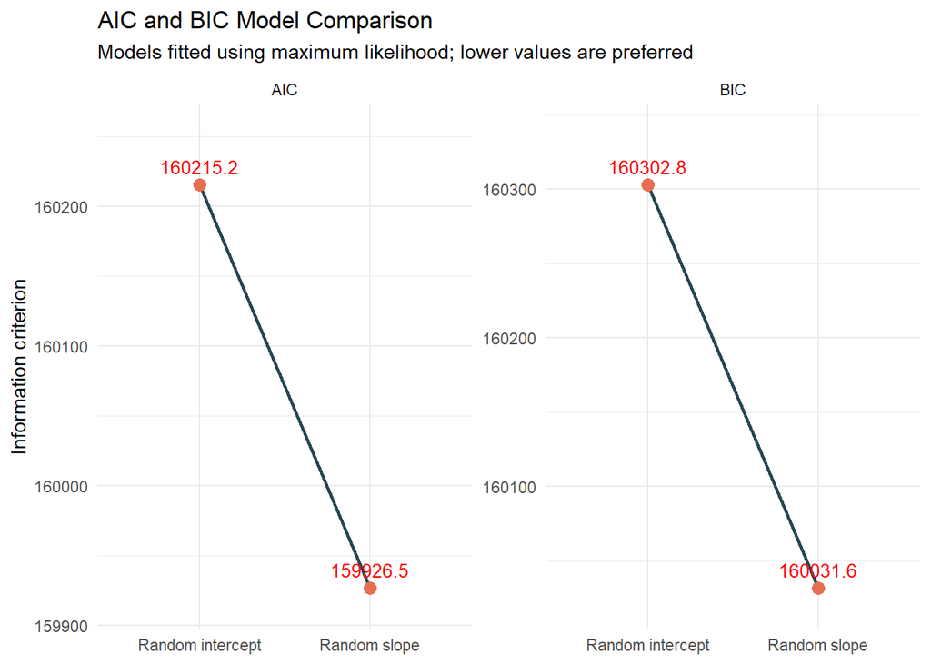

```r
############################################################
# FIGURE 1: AIC AND BIC COMPARISON
############################################################



# Collect AIC and BIC values from the ML-fitted models.
information_criteria <- data.frame(
  model = c(
    "Random intercept",
    "Random slope"
  ),
  AIC = c(
    AIC(m1_region_ml),
    AIC(m2_region_ml)
  ),
  BIC = c(
    BIC(m1_region_ml),
    BIC(m2_region_ml)
  )
) %>%
  # Arrange the criteria in separate rows for plotting.
  pivot_longer(
    cols = c(AIC, BIC),
    names_to = "criterion",
    values_to = "value"
  ) %>%
  # Keep the models in the intended order.
  mutate(
    model = factor(
      model,
      levels = c("Random intercept", "Random slope")
    )
  )

# Plot each information criterion in a separate panel.
aic_bic_plot <- ggplot(
  information_criteria,
  aes(
    x = model,
    y = value,
    group = 1
  )
) +
  geom_line(
    colour = "#264653",
    linewidth = 0.8
  ) +
  geom_point(
    colour = "#E76F51",
    size = 3
  ) +
  geom_text(
    aes(label = round(value, 1)),
    vjust = -0.8,
     colour = "#FF0000",
    size = 3.5
  ) +
  facet_wrap(
    ~ criterion,
    scales = "free_y"
  ) +
  scale_y_continuous(
    expand = expansion(mult = c(0.10, 0.20))
  ) +
  labs(
    title = "AIC and BIC Model Comparison",
    subtitle = "Models fitted using maximum likelihood; lower values are preferred",
    x = NULL,
    y = "Information criterion"
  ) +
  theme_minimal()

# Display the figure.
print(aic_bic_plot)
```

## Model comparison using AIC and BIC

The random-intercept and random-slope models were compared using maximum-likelihood estimation. AIC and BIC assess the balance between model fit and complexity, with lower values indicating a preferable model.

| Model | Estimated parameters | AIC | BIC |
| --- | --- | --- | --- |
| Random intercept | 10 | 160215.2 | 160302.8 |
| Random slope | 12 | 159926.5 | 160031.6 |

The random-slope model reduces **AIC by approximately 288.7** and **BIC by approximately 271.2**. Both criteria therefore favour this model: its improvement in fit outweighs the penalty for estimating additional parameters.

The likelihood-ratio test assesses whether adding regional variation in the religiosity slope improves fit compared with the random-intercept model. The ML-based comparison reports:
$$\chi^2(2)=292.72,\qquad p<.001.$$
The two degrees of freedom correspond to the additional **random-slope variance** and **intercept–slope covariance**. The large test statistic provides strong evidence that allowing the religiosity association to vary across regions improves model fit. The reported p-value uses an approximate chi-square reference distribution because zero slope variance lies on the boundary of the parameter space. Nevertheless, the likelihood-ratio result and the lower AIC and BIC values consistently favour the random-slope specification. We therefore retain the **random-slope model as the preferred model among these two regional specifications**. This supports modelling regional differences in the association between self-rated religiosity and trust in parliament, after adjustment for the other predictors.

## Visualising regional differences in the religiosity slope

The figure displays the 15 lowest and 15 highest estimated regional deviations from the average religiosity slope.

The zero line represents a regional slope equal to the model’s average slope, approximately 0.086. A negative deviation indicates a slope below this average; the regional association itself may still be positive.

Error bars show approximate 95% conditional intervals, treating the estimated model parameters as fixed.

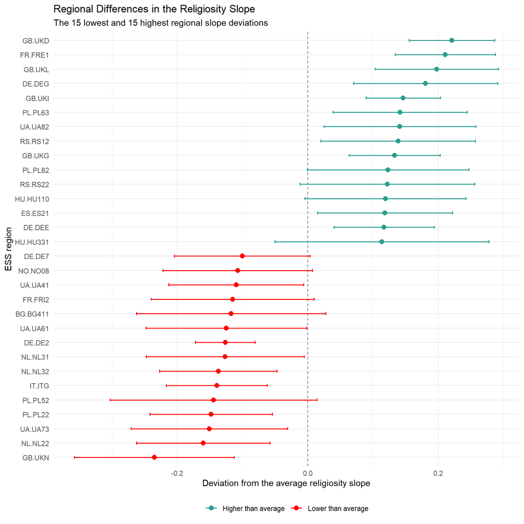

```r
############################################################
# VISUALISE THE REGIONAL RANDOM SLOPES
############################################################


# Extract regional deviations from the average religiosity
# slope and their conditional uncertainty from the REML model.
region_slope_effects <- as.data.frame(
  lme4::ranef(
    m2_region,
    condVar = TRUE
  )
) %>%
  filter(
    grpvar == "region_id",
    term == "rlgdgr_z"
  ) %>%
  transmute(
    region = as.character(grp),
    slope_deviation = condval,
    standard_error = condsd,
    lower = slope_deviation - 1.96 * standard_error,
    upper = slope_deviation + 1.96 * standard_error
  )

# Select the 15 lowest and 15 highest slope deviations.
extreme_region_slopes <- bind_rows(
  region_slope_effects %>%
    slice_min(
      slope_deviation,
      n = 15,
      with_ties = FALSE
    ),
  region_slope_effects %>%
    slice_max(
      slope_deviation,
      n = 15,
      with_ties = FALSE
    )
) %>%
  distinct(
    region,
    .keep_all = TRUE
  ) %>%
  mutate(
    direction = ifelse(
      slope_deviation >= 0,
      "Higher than average",
      "Lower than average"
    ),
    region = reorder(
      region,
      slope_deviation
    )
  )

# Plot the regional slope deviations and conditional intervals.
region_slope_plot <- ggplot(
  extreme_region_slopes,
  aes(
    x = region,
    y = slope_deviation,
    colour = direction
  )
) +
  geom_hline(
    yintercept = 0,
    linetype = "dashed",
    colour = "grey40"
  ) +
  geom_errorbar(
    aes(
      ymin = lower,
      ymax = upper
    ),
    width = 0.20,
    linewidth = 0.6
  ) +
  geom_point(
    size = 2.5
  ) +
  coord_flip() +
  scale_colour_manual(
    values = c(
      "Higher than average" = "#2A9D8F",
      "Lower than average" = "#FF0000"
    )
  ) +
  labs(
    title = "Regional Differences in the Religiosity Slope",
    subtitle = "The 15 lowest and 15 highest regional slope deviations",
    x = "ESS region",
    y = "Deviation from the average religiosity slope",
    colour = NULL
  ) +
  theme_minimal() +
  theme(
    legend.position = "bottom"
  )

# Display the figure.
print(region_slope_plot)
```

Among the displayed regions, GB.UKD has the largest positive deviation from the average religiosity slope, while GB.UKN has the largest negative deviation. Several 95% conditional intervals exclude zero, supporting differences from the model’s average slope, whereas intervals crossing zero provide less clear evidence of such differences.

## Three-level null model

Before extending the random-slope model, we estimate a three-level null model with respondents nested within regions and regions nested within countries. Separate country and regional random intercepts distinguish between-country differences from additional differences between regions within countries.

The model contains no explanatory predictors. The existing `region_id` variable uniquely identifies regions across countries.

```r
############################################################
# THREE-LEVEL NULL MODEL
############################################################

# Level 1: respondents
# Level 2: regions
# Level 3: countries

# Estimate a null model with country and regional random intercepts.
m0_country <- lme4::lmer(
  trstprl_z ~
    1 +
    (1 | region_id) +
    (1 | cntry),
  data = ess_mlm,
  weights = weight,
  REML = TRUE,
  na.action = na.exclude
)

# Display the model results and estimated variance components.
summary(m0_country)
```

```
## Linear mixed model fit by REML ['lmerMod']
## Formula: trstprl_z ~ 1 + (1 | region_id) + (1 | cntry)
##    Data: ess_mlm
## Weights: weight
##
## REML criterion at convergence: 169482.4
##
## Scaled residuals:
##     Min      1Q  Median      3Q     Max
## -7.5225 -0.4426  0.0350  0.4562  7.4811
##
## Random effects:
##  Groups    Name        Variance Std.Dev.
##  region_id (Intercept) 0.02978  0.1726
##  cntry     (Intercept) 0.15995  0.3999
##  Residual              0.78753  0.8874
## Number of obs: 49118, groups:  region_id, 328; cntry, 30
##
## Fixed effects:
##             Estimate Std. Error t value
## (Intercept)  0.00549    0.07503   0.073
```

```r
# Calculate the overall model-based ICC.
icc_m0_country <- performance::icc(m0_country)

icc_m0_country
```

```
## # Intraclass Correlation Coefficient
##
##     Adjusted ICC: 0.194
##   Unadjusted ICC: 0.194
```

```r
# Separate the country and regional variance contributions.
icc_m0_by_group <- performance::icc(
  m0_country,
  by_group = TRUE
)

icc_m0_by_group
```

```
## # ICC by Group
##
## Group     |   ICC
## -----------------
## region_id | 0.030
## cntry     | 0.164
```

## Interpretation of the three-level null model

The model includes **49,118 respondents from 328 regions across 30 countries**. The reported model-based variance decomposition is:

| Component | Estimated variance | Proportion |
| --- | --- | --- |
| Countries | 0.15995 | 16.4% |
| Regions within countries | 0.02978 | 3.0% |
| Residual component | 0.78753 | 80.6% |

The combined country and regional ICC is **0.194**. Thus, approximately **19.4% of the variance in the reported decomposition is associated with geographical clustering**. Country differences account for most of this component, while regions contribute a smaller additional share within countries. This provides a rationale for including a country random intercept in the subsequent model.

The adjusted and unadjusted ICCs are identical because the null model contains no explanatory predictors. These percentages describe the model-based variance decomposition under the specified weights.

The null model includes more respondents than the models with predictors (49,118 versus 47,217), because missing values in those predictors do not exclude respondents from the null model.

## Three-level random-slope model

The model extends the regional random-slope model by adding a country random intercept. Both the intercept and the self-rated religiosity slope can vary across regions, while the country random intercept accounts for differences in baseline trust between countries.

The same explanatory and control variables are retained, and the model is estimated using REML.

```r
############################################################
# THREE-LEVEL RANDOM-SLOPE MODEL
############################################################

# Level 1: respondents
# Level 2: regions
# Level 3: countries

# Estimate regional random intercepts and religiosity slopes,
# together with an additional country random intercept.
m3_country <- lme4::lmer(
  trstprl_z ~
    rlgdgr_z +
    rlgatnd_rec_z +
    pray_rec_z +
    agea_rec_z +
    gndr_rec +
    eisced_rec_z +
    polintr_rec_z +
    (1 + rlgdgr_z | region_id) +
    (1 | cntry),
  data = ess_mlm,
  weights = weight,
  REML = TRUE,
  na.action = na.exclude
)

# Display coefficients and variance components.
summary(m3_country)
```

```
## Linear mixed model fit by REML ['lmerMod']
## Formula: trstprl_z ~ rlgdgr_z + rlgatnd_rec_z + pray_rec_z + agea_rec_z +
##     gndr_rec + eisced_rec_z + polintr_rec_z + (1 + rlgdgr_z |
##     region_id) + (1 | cntry)
##    Data: ess_mlm
## Weights: weight
##
## REML criterion at convergence: 159521
##
## Scaled residuals:
##     Min      1Q  Median      3Q     Max
## -9.4202 -0.4375  0.0348  0.4474  9.3267
##
## Random effects:
##  Groups    Name        Variance Std.Dev. Corr
##  region_id (Intercept) 0.021560 0.14683
##            rlgdgr_z    0.009434 0.09713  0.07
##  cntry     (Intercept) 0.145339 0.38123
##  Residual              0.729634 0.85419
## Number of obs: 47217, groups:  region_id, 328; cntry, 30
##
## Fixed effects:
##                Estimate Std. Error t value
## (Intercept)    0.013546   0.071501   0.189
## rlgdgr_z       0.083775   0.009328   8.981
## rlgatnd_rec_z  0.069216   0.006141  11.271
## pray_rec_z    -0.046249   0.006482  -7.135
## agea_rec_z    -0.070891   0.004210 -16.839
## gndr_rec      -0.009100   0.008509  -1.069
## eisced_rec_z   0.076804   0.004251  18.067
## polintr_rec_z  0.170031   0.004500  37.782
##
## Correlation of Fixed Effects:
##             (Intr) rlgdg_ rlgt__ pry_r_ ag_rc_ gndr_r escd__
## rlgdgr_z     0.007
## rlgtnd_rc_z  0.000 -0.223
## pray_rec_z   0.009 -0.300 -0.345
## agea_rec_z   0.009 -0.057  0.023 -0.076
## gndr_rec    -0.062 -0.028  0.031 -0.114 -0.035
## eisced_rc_z  0.009  0.026 -0.019  0.027  0.161 -0.085
## polntr_rc_z -0.012  0.004 -0.009 -0.011 -0.168  0.169 -0.282
```

```r
############################################################
# FIT STATISTICS FOR THE REML MODEL
############################################################

# Collect the fit statistics for the current REML fit.
m3_fit_statistics <- data.frame(
  model = "Regional random slope and country random intercept",
  REML_criterion = lme4::REMLcrit(m3_country),
  AIC = AIC(m3_country),
  BIC = BIC(m3_country),
  restricted_log_likelihood = as.numeric(
    logLik(m3_country, REML = TRUE)
  )
)

# Display the fit statistics.
m3_fit_statistics
```

```
##                                                model REML_criterion    AIC
## 1 Regional random slope and country random intercept         159521 159547
##        BIC restricted_log_likelihood
## 1 159660.9                 -79760.48
```

## Interpretation of the three-level random-slope model

The model includes **47,217 respondents from 328 regions across 30 countries**. The fixed-effect pattern remains similar to the regional random-slope model.

Self-rated religiosity has a positive average conditional association with trust ($\hat{\beta}=0.084$): a one-standard-deviation increase in religiosity corresponds, on average across regions, to approximately 0.084 standard deviations higher trust, holding the other predictors constant. Political interest retains the largest absolute coefficient among the standardised predictors ($0.170$). Education ($0.077$) and religious attendance ($0.069$) are positively associated with trust, while age ($-0.071$) and prayer frequency ($-0.046$) are negatively associated. The gender coefficient remains small relative to its standard error ($\hat{\beta}=-0.009$, $t=-1.069$).

| Random component | Estimated variance | Standard deviation |
| --- | --- | --- |
| Country intercept | 0.14534 | 0.381 |
| Regional intercept | 0.02156 | 0.147 |
| Regional religiosity slope | 0.00943 | 0.097 |
| Residual scale parameter | 0.72963 | 0.854 |

The regional-intercept variance decreases from **0.18885** in the regional model to **0.02156** after introducing country random intercepts. Much of the baseline variation previously attributed to regions is now represented at the country level. At average self-rated religiosity, country differences are therefore the larger component of the remaining geographical variation in trust.

The random-slope variance remains close to its previous estimate (0.00943 versus 0.00921). The model thus continues to estimate regional differences in the religiosity association after accounting for country differences in baseline trust.

The reported REML fit statistics are **AIC = 159547**, **BIC = 159660.9**, **restricted log-likelihood = −79760.48**, and **REML criterion ≈ 159521**. The next step compares this specification with the regional random-slope model using their ML fits.

## Comparing the regional and three-level random-slope models

We compare the regional random-slope model with the three-level model using maximum likelihood. Both models contain the same fixed predictors and regional random effects; the three-level model adds one parameter, the country-intercept variance.

```r
############################################################
# COMPARE M2 AND M3 USING MAXIMUM LIKELIHOOD
############################################################

# Refit the regional random-slope model using ML.
m2_region_ml <- update(
  m2_region,
  REML = FALSE
)

# Refit the three-level random-slope model using ML.
m3_country_ml <- update(
  m3_country,
  REML = FALSE
)

# Display the number of observations in each model.
nobs(m2_region_ml)
```

```
## [1] 47217
```

```r
nobs(m3_country_ml)
```

```
## [1] 47217
```

```r
# Verify that both models use the same observations.
stopifnot(
  identical(
    rownames(model.frame(m2_region_ml)),
    rownames(model.frame(m3_country_ml))
  )
)

# Compare the ML fits using a likelihood ratio test.
anova_m2_m3 <- anova(
  m2_region_ml,
  m3_country_ml,
  refit = FALSE
)

# Display AIC, BIC, log-likelihood and the test results.
anova_m2_m3
```

```
## Data: ess_mlm
## Models:
## m2_region_ml: trstprl_z ~ rlgdgr_z + rlgatnd_rec_z + pray_rec_z + agea_rec_z + gndr_rec + eisced_rec_z + polintr_rec_z + (1 + rlgdgr_z | region_id)
## m3_country_ml: trstprl_z ~ rlgdgr_z + rlgatnd_rec_z + pray_rec_z + agea_rec_z + gndr_rec + eisced_rec_z + polintr_rec_z + (1 + rlgdgr_z | region_id) + (1 | cntry)
##               npar    AIC    BIC logLik -2*log(L)  Chisq Df Pr(>Chisq)
## m2_region_ml    12 159926 160032 -79951    159902
## m3_country_ml   13 159484 159598 -79729    159458 444.47  1  < 2.2e-16 ***
## ---
## Signif. codes:  0 '***' 0.001 '**' 0.01 '*' 0.05 '.' 0.1 ' ' 1
```

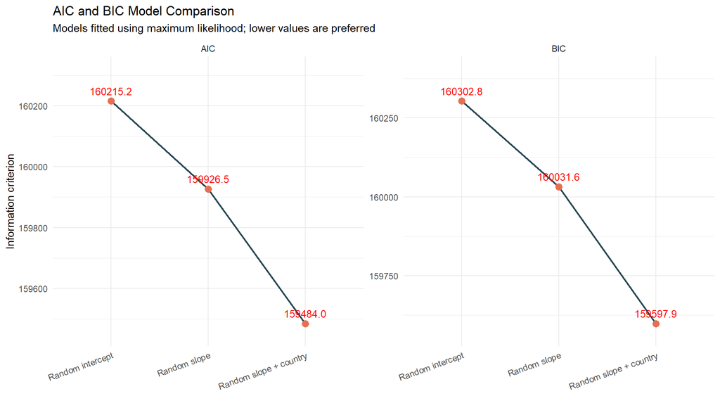

```r
############################################################
# AIC AND BIC COMPARISON: THREE MODELS
############################################################


# Collect information criteria from the three ML-fitted models.
information_criteria <- data.frame(
  model = c(
    "Random intercept",
    "Random slope",
    "Random slope + country"
  ),
  AIC = c(
    AIC(m1_region_ml),
    AIC(m2_region_ml),
    AIC(m3_country_ml)
  ),
  BIC = c(
    BIC(m1_region_ml),
    BIC(m2_region_ml),
    BIC(m3_country_ml)
  )
) %>%
  pivot_longer(
    cols = c(AIC, BIC),
    names_to = "criterion",
    values_to = "value"
  ) %>%
  mutate(
    model = factor(
      model,
      levels = c(
        "Random intercept",
        "Random slope",
        "Random slope + country"
      )
    )
  )

# Plot AIC and BIC in separate panels.
aic_bic_plot <- ggplot(
  information_criteria,
  aes(
    x = model,
    y = value,
    group = 1
  )
) +
  geom_line(
    colour = "#264653",
    linewidth = 0.8
  ) +
  geom_point(
    colour = "#E76F51",
    size = 3
  ) +
  geom_text(
    aes(label = sprintf("%.1f", value)),
    colour = "#FF0000",
    vjust = -0.8,
    size = 3.5
  ) +
  facet_wrap(
    ~ criterion,
    scales = "free_y"
  ) +
  scale_y_continuous(
    expand = expansion(mult = c(0.10, 0.20))
  ) +
  labs(
    title = "AIC and BIC Model Comparison",
    subtitle = "Models fitted using maximum likelihood; lower values are preferred",
    x = NULL,
    y = "Information criterion"
  ) +
  theme_minimal() +
  theme(
    axis.text.x = element_text(
      angle = 20,
      hjust = 1
    )
  )

# Display the figure.
print(aic_bic_plot)
```

## Interpretation of the model comparison

The regional and three-level random-slope models use the same **47,217 respondents**. The figure shows that AIC and BIC decrease across the three specifications, reaching their lowest values in the model with a country random intercept.

| Model | Estimated parameters | AIC | BIC |
| --- | --- | --- | --- |
| Regional random intercept | 10 | 160215.2 | 160302.8 |
| Regional random slope | 12 | 159926.5 | 160031.6 |
| Random slope + country intercept | 13 | 159484.0 | 159597.9 |

Adding the country random intercept reduces **AIC by approximately 442.5** and **BIC by approximately 433.7** relative to the regional random-slope model. The improvement in fit therefore outweighs the additional complexity according to both criteria.

The likelihood-ratio test reports:

$$\chi^2(1)=444.47,\qquad p<.001.$$

The single degree of freedom corresponds to the additional country-intercept variance. The result provides strong evidence that accounting for country-level clustering improves fit beyond the regional random effects and included predictors. The reported chi-square p-value is approximate because zero country variance lies on the boundary of the parameter space.

We therefore retain the **three-level random-slope model as the preferred specification among the three models examined**. Model selection is based on the ML comparisons, while substantive coefficients and variance components are reported from the REML-fitted model, `m3_country`.

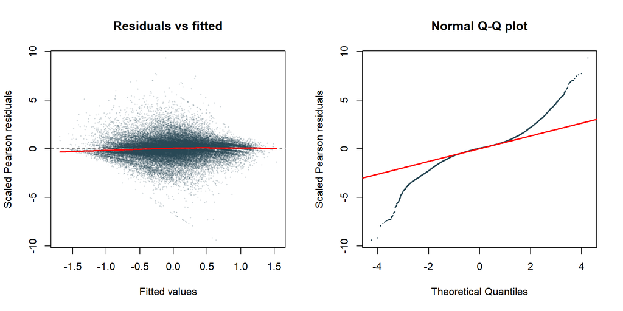

```r
# Extract fitted values and residuals adjusted for the model weights.
m3_diag <- na.omit(data.frame(
  fitted = fitted(m3_country),
  residual = residuals(m3_country, type = "pearson", scaled = TRUE)
))

m3_plot_settings <- par(mfrow = c(1, 2))

# Residuals versus fitted values.
plot(
  m3_diag$fitted, m3_diag$residual,
  main = "Residuals vs fitted",
  xlab = "Fitted values",
  ylab = "Scaled Pearson residuals",
  pch = 16, cex = 0.3,
  col = adjustcolor("#264653", alpha.f = 0.2)
)
abline(h = 0, col = "grey40", lty = 2)
lines(
  lowess(m3_diag$fitted, m3_diag$residual),
  col = "#FF0000", lwd = 2
)

# Normal Q-Q plot.
qqnorm(
  m3_diag$residual,
  main = "Normal Q-Q plot",
  ylab = "Scaled Pearson residuals",
  pch = 16, cex = 0.3,
  col = "#264653"
)
qqline(m3_diag$residual, col = "#FF0000", lwd = 2)
```

```r
par(m3_plot_settings)
```

We ran these diagnostics for the final three-level random-slope model (`m3_country`) to assess whether the remaining errors are compatible with its assumptions. The fitted values include both fixed and random effects, while the scaled Pearson residuals account for the supplied weights and estimated residual scale.

In the **residuals-versus-fitted plot**, the red smoothing line remains close to zero, showing little systematic pattern in average residuals across predicted trust levels. However, the residual spread is wider around intermediate fitted values and narrower towards the extremes. This suggests remaining heteroscedasticity: the weighting has not fully captured differences in residual variability.

The **normal Q–Q plot** compares the residual distribution with a normal distribution. Although the central observations approximately follow the reference line, both tails depart substantially from it. This indicates heavier tails, with more extreme prediction errors than the Gaussian assumption would suggest.

The model remains the preferred specification according to the earlier AIC and BIC comparisons, while these diagnostics identify limitations in its residual assumptions. Its coefficients can be reported as estimated conditional associations, but the model-based standard errors, confidence intervals and significance tests should be interpreted cautiously. The analysis therefore provides an approximate description of the relationships rather than evidence that all model assumptions are satisfied.